# SAS CU Hackathon

## Data Science Career Intelligence

### Project Objective

The objective of this project is to analyse the data science and analytics job market, identify important technical skills associated with junior career growth, and investigate personality traits associated with senior professional success.

```python
import pandas as pd
import numpy as np
import matplotlib.pyplot as plt

from pathlib import Path

from sklearn.model_selection import (
    train_test_split,
    cross_val_score,
    StratifiedKFold
)

from sklearn.preprocessing import StandardScaler

from sklearn.pipeline import Pipeline

from sklearn.linear_model import LogisticRegression

from sklearn.ensemble import RandomForestClassifier

from sklearn.metrics import (
    accuracy_score,
    precision_score,
    recall_score,
    f1_score,
    classification_report,
    confusion_matrix
)

from scipy.stats import ttest_ind

pd.set_option("display.max_columns", None)
pd.set_option("display.max_rows", 100)

print("All libraries imported successfully!")
```

```
All libraries imported successfully!
```

```python
DATA_DIR = Path("../data")

OUTPUT_DIR = Path("../outputs")

CHART_DIR = OUTPUT_DIR / "charts"

CLEAN_DIR = OUTPUT_DIR / "cleaned_data"

CHART_DIR.mkdir(parents=True, exist_ok=True)

CLEAN_DIR.mkdir(parents=True, exist_ok=True)

print("Folders configured successfully!")
```

```
Folders configured successfully!
```

```python
analytics = pd.read_csv(
    DATA_DIR / "Analytics Jobs.csv"
)

ds_jobs = pd.read_csv(
    DATA_DIR / "DataScience Jobs.csv"
)

jds = pd.read_excel(
    DATA_DIR / "JDS Skill Traits.xlsx"
)

sds = pd.read_excel(
    DATA_DIR / "SDS Personality Traits.xlsx"
)

print("All four datasets loaded successfully!")
```

```
All four datasets loaded successfully!
```

```python
print("Analytics Jobs:", analytics.shape)
print("Data Science Jobs:", ds_jobs.shape)
print("JDS Skill Traits:", jds.shape)
print("SDS Personality Traits:", sds.shape)
```

```
Analytics Jobs: (15841, 8)
Data Science Jobs: (1602, 8)
JDS Skill Traits: (139, 7)
SDS Personality Traits: (161, 7)
```

# 1. Data Understanding

Before performing data cleaning, we inspect each dataset to understand:

- Dataset dimensions
- Column names
- Data types
- Missing values
- Duplicate records
- Unique values
- Basic descriptive statistics

This ensures that cleaning decisions are based on the actual structure and quality of the data.

```python
# Display column names for all datasets

print("=== ANALYTICS JOBS ===")
print(analytics.columns.tolist())

print("\n=== DATA SCIENCE JOBS ===")
print(ds_jobs.columns.tolist())

print("\n=== JDS SKILL TRAITS ===")
print(jds.columns.tolist())

print("\n=== SDS PERSONALITY TRAITS ===")
print(sds.columns.tolist())
```

```
=== ANALYTICS JOBS ===
['s_no', 'experience', 'job_description', 'job_desig', 'job_type', 'key_skills', 'location', 'salary']

=== DATA SCIENCE JOBS ===
['reference_no', 'company_name', 'job_title', 'min_experience', 'avg_salary', 'min_salary', 'max_salary', 'num_of_jobs']

=== JDS SKILL TRAITS ===
['id', 'big_data_skills', 'maths-stats_skills', 'coding_skills', 'ai_and_ml_skills', 'dashboard_and_storytelling_skills', 'salary_hike_high_or_low']

=== SDS PERSONALITY TRAITS ===
['id', 'neuroticism', ' extraversion', 'openness_to_experience', 'agreeableness', 'conscientiousness', 'success_ classification_ high_low']
```

```python
print("=== ANALYTICS JOBS ===")
display(analytics.head())

print("=== DATA SCIENCE JOBS ===")
display(ds_jobs.head())

print("=== JDS SKILL TRAITS ===")
display(jds.head())

print("=== SDS PERSONALITY TRAITS ===")
display(sds.head())
```

```
=== ANALYTICS JOBS ===
```

|  | s_no | experience | job_description | job_desig | job_type | key_skills | location | salary |
| --- | --- | --- | --- | --- | --- | --- | --- | --- |
| 0 | 1 | 6-10 yrs | Must be knowledgeable and experienced in relat... | Oracle EBS Technical Consultant | NaN | Oracle SQL, PLSQL, PL, Oracle Forms, Oracle Re... | Bengaluru, Chennai | 6to10 |
| 1 | 2 | 8-12 yrs | - Experience in building scalable and highly a... | Staff Software Engineer - Object Oriented Anal... | NaN | Javascript, HTML, JQuery, Web Development, Pla... | Bengaluru | 10to15 |
| 2 | 3 | 3-8 yrs | NaN | Servicenow Developer | NaN | SNOW, Servicenow, Servicenow Developer | Hyderabad, Pune | 0to3 |
| 3 | 4 | 3-6 yrs | Our software engineers at Fiserv bring an... | Software Development Engineering, Analyst | NaN | QTP, Flex, LAN, Application support, Performan... | Pune | 6to10 |
| 4 | 5 | 5-10 yrs | - More than 5 years experience in Hypermesh fo... | NVH Engineer - Nastran/ Ls-dyna | NaN | HyperMesh, LS - DYNA, NASTRAN, Abaqus, Fatigue... | Mumbai, Bengaluru, Hyderabad, Pune, Delhi | 10to15 |

```
=== DATA SCIENCE JOBS ===
```

|  | reference_no | company_name | job_title | min_experience | avg_salary | min_salary | max_salary | num_of_jobs |
| --- | --- | --- | --- | --- | --- | --- | --- | --- |
| 0 | 7834 | TCS | Data Scientist | 2 | 7.8L | 4.5L | 16.0L | 841 |
| 1 | 7862 | Accenture | Data Scientist | 2 | 12.8L | 5.8L | 23.0L | 501 |
| 2 | 5925 | IBM | Data Scientist | 2 | 13.4L | 5.3L | 25.0L | 394 |
| 3 | 7578 | Cognizant | Data Scientist | 2 | 9.8L | 5.0L | 18.0L | 318 |
| 4 | 7177 | Capgemini | Data Scientist | 2 | 8.6L | 4.8L | 14.6L | 300 |

```
=== JDS SKILL TRAITS ===
```

|  | id | big_data_skills | maths-stats_skills | coding_skills | ai_and_ml_skills | dashboard_and_storytelling_skills | salary_hike_high_or_low |
| --- | --- | --- | --- | --- | --- | --- | --- |
| 0 | 2809 | 3.6 | 4.0 | 4.5 | 4.8 | 5.0 | 1 |
| 1 | 2231 | 5.0 | 3.8 | 3.3 | 5.0 | 4.4 | 0 |
| 2 | 3522 | 4.1 | 3.8 | 4.4 | 4.2 | 5.0 | 1 |
| 3 | 3291 | 4.4 | 3.0 | 3.3 | 4.6 | 2.3 | 0 |
| 4 | 3424 | 2.3 | 2.3 | 2.6 | 3.3 | 3.0 | 0 |

```
=== SDS PERSONALITY TRAITS ===
```

|  | id | neuroticism | extraversion | openness_to_experience | agreeableness | conscientiousness | success_ classification_ high_low |
| --- | --- | --- | --- | --- | --- | --- | --- |
| 0 | 8120 | 33 | 34 | 39 | 45 | 51 | 1 |
| 1 | 8951 | 50 | 36 | 31 | 59 | 39 | 0 |
| 2 | 8656 | 38 | 35 | 42 | 39 | 49 | 1 |
| 3 | 8796 | 41 | 26 | 30 | 40 | 19 | 0 |
| 4 | 8470 | 20 | 17 | 21 | 31 | 26 | 0 |

## 1.1 Data Types

The data types are checked to identify numerical, categorical, text, and date-related variables and to detect columns that may require conversion during cleaning.

```python
print("=== Analytics Jobs ===")
analytics.info()

print("\n=== Data Science Jobs ===")
ds_jobs.info()

print("\n=== JDS Skill Traits ===")
jds.info()

print("\n=== SDS Personality Traits ===")
sds.info()
```

```
=== Analytics Jobs ===
<class 'pandas.DataFrame'>
RangeIndex: 15841 entries, 0 to 15840
Data columns (total 8 columns):
 #   Column           Non-Null Count  Dtype
---  ------           --------------  -----
 0   s_no             15841 non-null  int64
 1   experience       15841 non-null  str
 2   job_description  12333 non-null  str
 3   job_desig        15841 non-null  str
 4   job_type         3830 non-null   str
 5   key_skills       15840 non-null  str
 6   location         15841 non-null  str
 7   salary           15841 non-null  str
dtypes: int64(1), str(7)
memory usage: 990.2 KB

=== Data Science Jobs ===
<class 'pandas.DataFrame'>
RangeIndex: 1602 entries, 0 to 1601
Data columns (total 8 columns):
 #   Column          Non-Null Count  Dtype
---  ------          --------------  -----
 0   reference_no    1602 non-null   int64
 1   company_name    1602 non-null   str
 2   job_title       1602 non-null   str
 3   min_experience  1602 non-null   int64
 4   avg_salary      1602 non-null   str
 5   min_salary      1602 non-null   str
 6   max_salary      1602 non-null   str
 7   num_of_jobs     1602 non-null   int64
dtypes: int64(3), str(5)
memory usage: 100.3 KB

=== JDS Skill Traits ===
<class 'pandas.DataFrame'>
RangeIndex: 139 entries, 0 to 138
Data columns (total 7 columns):
 #   Column                             Non-Null Count  Dtype
---  ------                             --------------  -----
```

[output cut: 10 more lines]

```
=== SDS Personality Traits ===
<class 'pandas.DataFrame'>
RangeIndex: 161 entries, 0 to 160
Data columns (total 7 columns):
 #   Column                             Non-Null Count  Dtype
---  ------                             --------------  -----
 0   id                                 161 non-null    int64
 1   neuroticism                        161 non-null    int64
 2    extraversion                      161 non-null    int64
 3   openness_to_experience             161 non-null    int64
 4   agreeableness                      161 non-null    int64
 5   conscientiousness                  161 non-null    int64
 6   success_ classification_ high_low  161 non-null    int64
dtypes: int64(7)
memory usage: 8.9 KB
```

## 1.2 Missing Value Analysis

Missing values are identified before cleaning so that appropriate treatment can be applied to each variable rather than removing information unnecessarily.

```python
missing_summary = pd.DataFrame({
    "Analytics Jobs": analytics.isna().sum(),
    "Data Science Jobs": ds_jobs.isna().sum(),
    "JDS Skill Traits": jds.isna().sum(),
    "SDS Personality Traits": sds.isna().sum()
})

display(missing_summary)
```

|  | Analytics Jobs | Data Science Jobs | JDS Skill Traits | SDS Personality Traits |
| --- | --- | --- | --- | --- |
| extraversion | NaN | NaN | NaN | 0.0 |
| agreeableness | NaN | NaN | NaN | 0.0 |
| ai_and_ml_skills | NaN | NaN | 0.0 | NaN |
| avg_salary | NaN | 0.0 | NaN | NaN |
| big_data_skills | NaN | NaN | 0.0 | NaN |
| coding_skills | NaN | NaN | 0.0 | NaN |
| company_name | NaN | 0.0 | NaN | NaN |
| conscientiousness | NaN | NaN | NaN | 0.0 |
| dashboard_and_storytelling_skills | NaN | NaN | 0.0 | NaN |
| experience | 0.0 | NaN | NaN | NaN |
| id | NaN | NaN | 0.0 | 0.0 |
| job_description | 3508.0 | NaN | NaN | NaN |
| job_desig | 0.0 | NaN | NaN | NaN |
| job_title | NaN | 0.0 | NaN | NaN |
| job_type | 12011.0 | NaN | NaN | NaN |
| key_skills | 1.0 | NaN | NaN | NaN |
| location | 0.0 | NaN | NaN | NaN |
| maths-stats_skills | NaN | NaN | 0.0 | NaN |
| max_salary | NaN | 0.0 | NaN | NaN |
| min_experience | NaN | 0.0 | NaN | NaN |
| min_salary | NaN | 0.0 | NaN | NaN |
| neuroticism | NaN | NaN | NaN | 0.0 |
| num_of_jobs | NaN | 0.0 | NaN | NaN |
| openness_to_experience | NaN | NaN | NaN | 0.0 |
| reference_no | NaN | 0.0 | NaN | NaN |
| s_no | 0.0 | NaN | NaN | NaN |
| salary | 0.0 | NaN | NaN | NaN |
| salary_hike_high_or_low | NaN | NaN | 0.0 | NaN |
| success_ classification_ high_low | NaN | NaN | NaN | 0.0 |

```python
def missing_report(df):
    result = pd.DataFrame({
        "Missing Count": df.isna().sum(),
        "Missing %": (df.isna().mean() * 100).round(2)
    })
    return result.sort_values("Missing Count", ascending=False)


print("=== Analytics Jobs ===")
display(missing_report(analytics))

print("=== Data Science Jobs ===")
display(missing_report(ds_jobs))

print("=== JDS Skill Traits ===")
display(missing_report(jds))

print("=== SDS Personality Traits ===")
display(missing_report(sds))
```

```
=== Analytics Jobs ===
```

|  | Missing Count | Missing % |
| --- | --- | --- |
| job_type | 12011 | 75.82 |
| job_description | 3508 | 22.15 |
| key_skills | 1 | 0.01 |
| s_no | 0 | 0.00 |
| job_desig | 0 | 0.00 |
| experience | 0 | 0.00 |
| location | 0 | 0.00 |
| salary | 0 | 0.00 |

```
=== Data Science Jobs ===
```

|  | Missing Count | Missing % |
| --- | --- | --- |
| reference_no | 0 | 0.0 |
| company_name | 0 | 0.0 |
| job_title | 0 | 0.0 |
| min_experience | 0 | 0.0 |
| avg_salary | 0 | 0.0 |
| min_salary | 0 | 0.0 |
| max_salary | 0 | 0.0 |
| num_of_jobs | 0 | 0.0 |

```
=== JDS Skill Traits ===
```

|  | Missing Count | Missing % |
| --- | --- | --- |
| id | 0 | 0.0 |
| big_data_skills | 0 | 0.0 |
| maths-stats_skills | 0 | 0.0 |
| coding_skills | 0 | 0.0 |
| ai_and_ml_skills | 0 | 0.0 |
| dashboard_and_storytelling_skills | 0 | 0.0 |
| salary_hike_high_or_low | 0 | 0.0 |

```
=== SDS Personality Traits ===
```

|  | Missing Count | Missing % |
| --- | --- | --- |
| id | 0 | 0.0 |
| neuroticism | 0 | 0.0 |
| extraversion | 0 | 0.0 |
| openness_to_experience | 0 | 0.0 |
| agreeableness | 0 | 0.0 |
| conscientiousness | 0 | 0.0 |
| success_ classification_ high_low | 0 | 0.0 |

## 1.3 Duplicate Record Analysis

Duplicate records are checked because repeated observations can distort frequencies, distributions, and statistical analysis.

```python
duplicate_summary = pd.DataFrame({
    "Dataset": [
        "Analytics Jobs",
        "Data Science Jobs",
        "JDS Skill Traits",
        "SDS Personality Traits"
    ],
    "Duplicate Rows": [
        analytics.duplicated().sum(),
        ds_jobs.duplicated().sum(),
        jds.duplicated().sum(),
        sds.duplicated().sum()
    ]
})

display(duplicate_summary)
```

|  | Dataset | Duplicate Rows |
| --- | --- | --- |
| 0 | Analytics Jobs | 0 |
| 1 | Data Science Jobs | 0 |
| 2 | JDS Skill Traits | 0 |
| 3 | SDS Personality Traits | 0 |

## 1.4 Descriptive Statistics

Descriptive statistics are used to understand the numerical variables, including their central tendency, dispersion, and range.

```python
print("=== Analytics Jobs ===")
display(analytics.describe(include="all").T)

print("=== Data Science Jobs ===")
display(ds_jobs.describe(include="all").T)

print("=== JDS Skill Traits ===")
display(jds.describe(include="all").T)

print("=== SDS Personality Traits ===")
display(sds.describe(include="all").T)
```

```
=== Analytics Jobs ===
```

|  | count | unique | top | freq | mean | std | min | 25% | 50% | 75% | max |
| --- | --- | --- | --- | --- | --- | --- | --- | --- | --- | --- | --- |
| s_no | 15841.0 | NaN | NaN | NaN | 7921.0 | 4573.047142 | 1.0 | 3961.0 | 7921.0 | 11881.0 | 15841.0 |
| experience | 15841 | 128 | 5-10 yrs | 1010 | NaN | NaN | NaN | NaN | NaN | NaN | NaN |
| job_description | 12333 | 7859 | Accenture Technology powers our clients busine... | 117 | NaN | NaN | NaN | NaN | NaN | NaN | NaN |
| job_desig | 15841 | 10097 | Business Analyst | 108 | NaN | NaN | NaN | NaN | NaN | NaN | NaN |
| job_type | 3830 | 5 | Analytics | 2971 | NaN | NaN | NaN | NaN | NaN | NaN | NaN |
| key_skills | 15840 | 11155 | part time, freelancing, data entry, present jo... | 66 | NaN | NaN | NaN | NaN | NaN | NaN | NaN |
| location | 15841 | 1355 | Bengaluru | 3333 | NaN | NaN | NaN | NaN | NaN | NaN | NaN |
| salary | 15841 | 6 | 10to15 | 3608 | NaN | NaN | NaN | NaN | NaN | NaN | NaN |

```
=== Data Science Jobs ===
```

|  | count | unique | top | freq | mean | std | min | 25% | 50% | 75% | max |
| --- | --- | --- | --- | --- | --- | --- | --- | --- | --- | --- | --- |
| reference_no | 1602.0 | NaN | NaN | NaN | 5105.789014 | 2291.937727 | 1012.0 | 3225.25 | 5200.5 | 7022.5 | 8998.0 |
| company_name | 1602 | 642 | TCS | 10 | NaN | NaN | NaN | NaN | NaN | NaN | NaN |
| job_title | 1602 | 10 | Data Scientist | 188 | NaN | NaN | NaN | NaN | NaN | NaN | NaN |
| min_experience | 1602.0 | NaN | NaN | NaN | 2.799001 | 2.353686 | 0.0 | 1.0 | 2.0 | 4.0 | 21.0 |
| avg_salary | 1602 | 305 | 9.7L | 16 | NaN | NaN | NaN | NaN | NaN | NaN | NaN |
| min_salary | 1602 | 197 | 5.0L | 62 | NaN | NaN | NaN | NaN | NaN | NaN | NaN |
| max_salary | 1602 | 304 | 20.0L | 63 | NaN | NaN | NaN | NaN | NaN | NaN | NaN |
| num_of_jobs | 1602.0 | NaN | NaN | NaN | 58.055556 | 169.042138 | 3.0 | 9.25 | 22.0 | 47.0 | 4200.0 |

```
=== JDS Skill Traits ===
```

|  | count | mean | std | min | 25% | 50% | 75% | max |
| --- | --- | --- | --- | --- | --- | --- | --- | --- |
| id | 139.0 | 2958.460432 | 604.538742 | 2007.0 | 2383.50 | 2963.0 | 3452.0 | 4000.0 |
| big_data_skills | 139.0 | 3.849640 | 0.846594 | 2.3 | 3.10 | 3.8 | 4.6 | 5.0 |
| maths-stats_skills | 139.0 | 4.293525 | 0.843922 | 2.2 | 3.80 | 4.6 | 5.0 | 5.0 |
| coding_skills | 139.0 | 4.268345 | 0.892971 | 2.2 | 3.35 | 4.6 | 5.0 | 5.0 |
| ai_and_ml_skills | 139.0 | 4.566187 | 0.667089 | 2.2 | 4.40 | 4.9 | 5.0 | 5.0 |
| dashboard_and_storytelling_skills | 139.0 | 4.355396 | 0.933062 | 2.3 | 3.75 | 5.0 | 5.0 | 5.0 |
| salary_hike_high_or_low | 139.0 | 0.525180 | 0.501172 | 0.0 | 0.00 | 1.0 | 1.0 | 1.0 |

```
=== SDS Personality Traits ===
```

|  | count | mean | std | min | 25% | 50% | 75% | max |
| --- | --- | --- | --- | --- | --- | --- | --- | --- |
| id | 161.0 | 8484.596273 | 280.357503 | 8001.0 | 8228.0 | 8504.0 | 8729.0 | 8979.0 |
| neuroticism | 161.0 | 36.192547 | 11.268050 | 17.0 | 27.0 | 34.0 | 44.0 | 68.0 |
| extraversion | 161.0 | 43.204969 | 12.134722 | 17.0 | 34.0 | 45.0 | 53.0 | 67.0 |
| openness_to_experience | 161.0 | 41.329193 | 11.322420 | 18.0 | 32.0 | 44.0 | 49.0 | 65.0 |
| agreeableness | 161.0 | 44.602484 | 11.293405 | 17.0 | 39.0 | 46.0 | 51.0 | 68.0 |
| conscientiousness | 161.0 | 45.211180 | 13.211931 | 18.0 | 35.0 | 49.0 | 56.0 | 66.0 |
| success_ classification_ high_low | 161.0 | 0.527950 | 0.500776 | 0.0 | 0.0 | 1.0 | 1.0 | 1.0 |

## 1.5 Overall Data Quality Summary

The following summary provides an initial assessment of the size, missing values, and duplicate records across all four datasets.

```python
data_quality_summary = pd.DataFrame({
    "Dataset": [
        "Analytics Jobs",
        "Data Science Jobs",
        "JDS Skill Traits",
        "SDS Personality Traits"
    ],

    "Rows": [
        len(analytics),
        len(ds_jobs),
        len(jds),
        len(sds)
    ],

    "Columns": [
        len(analytics.columns),
        len(ds_jobs.columns),
        len(jds.columns),
        len(sds.columns)
    ],

    "Missing Values": [
        analytics.isna().sum().sum(),
        ds_jobs.isna().sum().sum(),
        jds.isna().sum().sum(),
        sds.isna().sum().sum()
    ],

    "Duplicate Rows": [
        analytics.duplicated().sum(),
        ds_jobs.duplicated().sum(),
        jds.duplicated().sum(),
        sds.duplicated().sum()
    ]
})

display(data_quality_summary)
```

|  | Dataset | Rows | Columns | Missing Values | Duplicate Rows |
| --- | --- | --- | --- | --- | --- |
| 0 | Analytics Jobs | 15841 | 8 | 15520 | 0 |
| 1 | Data Science Jobs | 1602 | 8 | 0 | 0 |
| 2 | JDS Skill Traits | 139 | 7 | 0 | 0 |
| 3 | SDS Personality Traits | 161 | 7 | 0 | 0 |

# 2. Data Cleaning

## 2.1 Detailed Missing-Value Investigation

The initial quality assessment identified missing values in the Analytics Jobs dataset.

Before deciding how to handle these missing values, we examine the missing-value count and percentage for each column.

```python
analytics_missing = pd.DataFrame({
    "Missing Count": analytics.isna().sum(),
    "Missing Percentage": (
        analytics.isna().mean() * 100
    ).round(2)
})

analytics_missing = analytics_missing.sort_values(
    "Missing Count",
    ascending=False
)

display(analytics_missing)
```

|  | Missing Count | Missing Percentage |
| --- | --- | --- |
| job_type | 12011 | 75.82 |
| job_description | 3508 | 22.15 |
| key_skills | 1 | 0.01 |
| s_no | 0 | 0.00 |
| job_desig | 0 | 0.00 |
| experience | 0 | 0.00 |
| location | 0 | 0.00 |
| salary | 0 | 0.00 |

```python
print("Analytics Jobs columns:")
for i, column in enumerate(analytics.columns, start=1):
    print(f"{i}. {column}")
```

```
Analytics Jobs columns:
1. s_no
2. experience
3. job_description
4. job_desig
5. job_type
6. key_skills
7. location
8. salary
```

```python
display(analytics.head(10))
```

|  | s_no | experience | job_description | job_desig | job_type | key_skills | location | salary |
| --- | --- | --- | --- | --- | --- | --- | --- | --- |
| 0 | 1 | 6-10 yrs | Must be knowledgeable and experienced in relat... | Oracle EBS Technical Consultant | NaN | Oracle SQL, PLSQL, PL, Oracle Forms, Oracle Re... | Bengaluru, Chennai | 6to10 |
| 1 | 2 | 8-12 yrs | - Experience in building scalable and highly a... | Staff Software Engineer - Object Oriented Anal... | NaN | Javascript, HTML, JQuery, Web Development, Pla... | Bengaluru | 10to15 |
| 2 | 3 | 3-8 yrs | NaN | Servicenow Developer | NaN | SNOW, Servicenow, Servicenow Developer | Hyderabad, Pune | 0to3 |
| 3 | 4 | 3-6 yrs | Our software engineers at Fiserv bring an... | Software Development Engineering, Analyst | NaN | QTP, Flex, LAN, Application support, Performan... | Pune | 6to10 |
| 4 | 5 | 5-10 yrs | - More than 5 years experience in Hypermesh fo... | NVH Engineer - Nastran/ Ls-dyna | NaN | HyperMesh, LS - DYNA, NASTRAN, Abaqus, Fatigue... | Mumbai, Bengaluru, Hyderabad, Pune, Delhi | 10to15 |
| 5 | 6 | 4-9 yrs | - Experience in digital, always-on systems lik... | Manager - Portfolio Analytics - NBFC - Iit/nit... | Analytics | Manager - Portfolio Analytics, Portfolio Analy... | Chennai, Pune | 15to25 |
| 6 | 7 | 5-7 yrs | 5-7 years of experience;Should understand tech... | Head Delivery-providers | Analytics | Project Management, Client Interfacing, Client... | Delhi NCR | 3to6 |
| 7 | 8 | 0-0 yrs | NaN | Fresher Analytics ( Hiring for Analyst \| Data ... | Analytics | Analysis, research, analyst, research analyst,... | Delhi NCR, Faridabad, Ghaziabad, Greater Noida... | 0to3 |
| 8 | 9 | 6-11 yrs | We are looking to hire a hands-on expert with ... | Team Leader Operations - Digital Marketing | NaN | SEO, Digital Marketing, Search Engine Marketin... | Mumbai, Mumbai Suburbs | 6to10 |
| 9 | 10 | 1-6 yrs | NaN | Senior Manager Collections@ Two Wheeler Financ... | NaN | recovery, team handling, data analysis, team l... | Thane | 0to3 |

## 2.2 Missing Values by Column

The following visualization shows the number of missing observations in each Analytics Jobs variable.

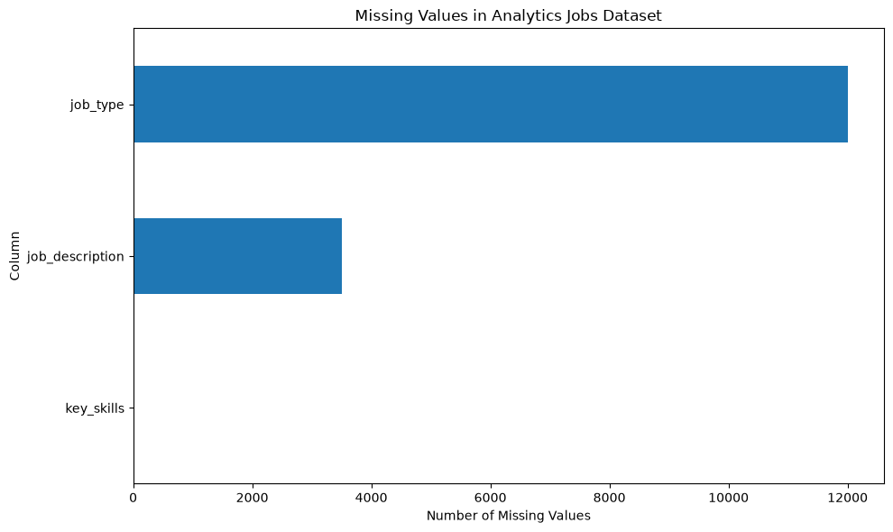

```python
missing_counts = analytics.isna().sum()

missing_counts = missing_counts[
    missing_counts > 0
].sort_values(ascending=True)

plt.figure(figsize=(10, 6))

missing_counts.plot(kind="barh")

plt.title("Missing Values in Analytics Jobs Dataset")
plt.xlabel("Number of Missing Values")
plt.ylabel("Column")

plt.tight_layout()

plt.show()
```

```python
analytics["missing_count"] = analytics.isna().sum(axis=1)

display(
    analytics["missing_count"]
    .value_counts()
    .sort_index()
)
```

```
missing_count
0    3105
1    9952
2    2784
Name: count, dtype: int64
```

```python
display(
    analytics[
        analytics.isna().any(axis=1)
    ].head(20)
)
```

|  | s_no | experience | job_description | job_desig | job_type | key_skills | location | salary | missing_count |
| --- | --- | --- | --- | --- | --- | --- | --- | --- | --- |
| 0 | 1 | 6-10 yrs | Must be knowledgeable and experienced in relat... | Oracle EBS Technical Consultant | NaN | Oracle SQL, PLSQL, PL, Oracle Forms, Oracle Re... | Bengaluru, Chennai | 6to10 | 1 |
| 1 | 2 | 8-12 yrs | - Experience in building scalable and highly a... | Staff Software Engineer - Object Oriented Anal... | NaN | Javascript, HTML, JQuery, Web Development, Pla... | Bengaluru | 10to15 | 1 |
| 2 | 3 | 3-8 yrs | NaN | Servicenow Developer | NaN | SNOW, Servicenow, Servicenow Developer | Hyderabad, Pune | 0to3 | 2 |
| 3 | 4 | 3-6 yrs | Our software engineers at Fiserv bring an... | Software Development Engineering, Analyst | NaN | QTP, Flex, LAN, Application support, Performan... | Pune | 6to10 | 1 |
| 4 | 5 | 5-10 yrs | - More than 5 years experience in Hypermesh fo... | NVH Engineer - Nastran/ Ls-dyna | NaN | HyperMesh, LS - DYNA, NASTRAN, Abaqus, Fatigue... | Mumbai, Bengaluru, Hyderabad, Pune, Delhi | 10to15 | 1 |
| 7 | 8 | 0-0 yrs | NaN | Fresher Analytics ( Hiring for Analyst \| Data ... | Analytics | Analysis, research, analyst, research analyst,... | Delhi NCR, Faridabad, Ghaziabad, Greater Noida... | 0to3 | 1 |
| 8 | 9 | 6-11 yrs | We are looking to hire a hands-on expert with ... | Team Leader Operations - Digital Marketing | NaN | SEO, Digital Marketing, Search Engine Marketin... | Mumbai, Mumbai Suburbs | 6to10 | 1 |
| 9 | 10 | 1-6 yrs | NaN | Senior Manager Collections@ Two Wheeler Financ... | NaN | recovery, team handling, data analysis, team l... | Thane | 0to3 | 2 |
| 10 | 11 | 2-7 yrs | NaN | Analytics Specialist | Analytics | Analytics, Data analysis, Data mining, SQL, Tr... | Gurgaon, Mumbai | 6to10 | 1 |
| 11 | 12 | 5-9 yrs | - Have good time management skills and should ... | Data Science & Machine Learning Role - Python/... | NaN | Data Science, SCALA, Machine Learning, Java, P... | Gurgaon | 15to25 | 1 |
| 12 | 13 | 9-14 yrs | - Must have experience in designing and archit... | Big Data Architect/specialist - Java/hadoop | NaN | Java, J2Ee, Spring Framework, Hadoop, Mapreduc... | Bengaluru, Delhi NCR | 25to50 | 1 |
| 14 | 15 | 8-12 yrs | NaN | Manager-electronics Commodity | NaN | process monitoring, cost reduction initiatives... | Delhi NCR | 15to25 | 2 |
| 15 | 16 | 0-3 yrs | Should be focused on quality and error free re... | Analyst - Background Verification (Day Shift) | NaN | background verification, backend, back office,... | Kolkata(Salt Lake) | 0to3 | 1 |
| 17 | 18 | 2-3 yrs | NaN | Executive - Social Media | NaN | Digital Marketing, Content Strategy, Digital M... | Mumbai(Lower Parel) | 0to3 | 2 |
| 18 | 19 | 0-5 yrs | - should possess excellent communication skill... | Executive - Audit Finance and Accounts | NaN | finance, auditing, accounting, financial repor... | Bengaluru, Chennai, Kochi | 0to3 | 1 |
| 20 | 21 | 5-10 yrs | 5+ years of credit experience with credit scor... | Credit Manager - Home Loans l Kakinada, Karimn... | NaN | Credit Management, Home Loans, Credit Manager,... | Kakinada, Karimnagar | 3to6 | 1 |
| 21 | 22 | 3-8 yrs | Should have strong client handling experience;... | Assistant Manager Recruitment and Client Manag... | NaN | Head Hunting, Recruitment, Screening, Leadersh... | Delhi NCR(Old Rajender Nagar) | 0to3 | 1 |
| 22 | 23 | 2-6 yrs | Anyone who is having relevant experience can ... | Sales Associate | NaN | Event Sales, Space Selling, Ad Sales, Project ... | Hyderabad | 0to3 | 1 |
| 23 | 24 | 4-6 yrs | Key Skills: Matlab, Image Processing, C++, Mac... | Image Processing Engineer - Machine Learning/o... | NaN | opencv, c++, image processing, matlab, algorit... | Mumbai | 6to10 | 1 |
| 25 | 26 | 2-5 yrs | Should have strong problem-solving skills and ... | Urgent Opening for Campaign Success Manager | NaN | Digital Marketing, Business Development, Socia... | Gurgaon | 6to10 | 1 |

```python
# Exact missing-value report for the original Analytics Jobs columns

analytics_missing = pd.DataFrame({
    "Missing Count": analytics.isna().sum(),
    "Missing Percentage": (
        analytics.isna().mean() * 100
    ).round(2)
})

analytics_missing = analytics_missing.sort_values(
    "Missing Count",
    ascending=False
)

display(analytics_missing)
```

|  | Missing Count | Missing Percentage |
| --- | --- | --- |
| job_type | 12011 | 75.82 |
| job_description | 3508 | 22.15 |
| key_skills | 1 | 0.01 |
| s_no | 0 | 0.00 |
| experience | 0 | 0.00 |
| job_desig | 0 | 0.00 |
| location | 0 | 0.00 |
| salary | 0 | 0.00 |
| missing_count | 0 | 0.00 |

```python
# Display the original column names

print("Analytics Jobs columns:")
for i, column in enumerate(analytics.columns, start=1):
    print(f"{i}. {column}")
```

```
Analytics Jobs columns:
1. s_no
2. experience
3. job_description
4. job_desig
5. job_type
6. key_skills
7. location
8. salary
9. missing_count
```

```python
# Number of missing values by column

for column in analytics.columns:
    missing = analytics[column].isna().sum()
    percentage = analytics[column].isna().mean() * 100

    print(
        f"{column}: "
        f"{missing} missing "
        f"({percentage:.2f}%)"
    )
```

```
s_no: 0 missing (0.00%)
experience: 0 missing (0.00%)
job_description: 3508 missing (22.15%)
job_desig: 0 missing (0.00%)
job_type: 12011 missing (75.82%)
key_skills: 1 missing (0.01%)
location: 0 missing (0.00%)
salary: 0 missing (0.00%)
missing_count: 0 missing (0.00%)
```

```python
analytics["missing_count"] = analytics.isna().sum(axis=1)
```

```python
display(analytics_missing)
```

|  | Missing Count | Missing Percentage |
| --- | --- | --- |
| job_type | 12011 | 75.82 |
| job_description | 3508 | 22.15 |
| key_skills | 1 | 0.01 |
| s_no | 0 | 0.00 |
| experience | 0 | 0.00 |
| job_desig | 0 | 0.00 |
| location | 0 | 0.00 |
| salary | 0 | 0.00 |
| missing_count | 0 | 0.00 |

```python
display(
    analytics["job_type"].value_counts(dropna=False)
)
```

```
job_type
NaN          12011
Analytics     2971
analytics      746
ANALYTICS       64
analytic        30
Analytic        19
Name: count, dtype: int64
```

```python
print("Missing job descriptions:",
      analytics["job_description"].isna().sum())

print("Available job descriptions:",
      analytics["job_description"].notna().sum())
```

```
Missing job descriptions: 3508
Available job descriptions: 12333
```

```python
display(
    analytics[
        analytics["key_skills"].isna()
    ]
)
```

|  | s_no | experience | job_description | job_desig | job_type | key_skills | location | salary | missing_count |
| --- | --- | --- | --- | --- | --- | --- | --- | --- | --- |
| 7809 | 7810 | 8-12 yrs | NaN | Analytics Translators | Analytics | NaN | Mumbai | 6to10 | 2 |

```python
analytics_clean = analytics.copy()

print("Original rows:", len(analytics))
print("Clean dataset rows:", len(analytics_clean))
```

```
Original rows: 15841
Clean dataset rows: 15841
```

```python
analytics_clean = analytics_clean.drop(
    columns=["missing_count"],
    errors="ignore"
)

print(analytics_clean.columns.tolist())
```

```
['s_no', 'experience', 'job_description', 'job_desig', 'job_type', 'key_skills', 'location', 'salary']
```

```python
analytics_clean["job_type"] = (
    analytics_clean["job_type"]
    .astype("string")
    .str.strip()
    .str.lower()
)
```

```python
analytics_clean["job_type"] = analytics_clean["job_type"].replace({
    "analytics": "Analytics",
    "analytic": "Analytics"
})
```

```python
analytics_clean["job_type"] = (
    analytics_clean["job_type"]
    .fillna("Not Specified")
)
```

```python
print("Job type categories after cleaning:")

display(
    analytics_clean["job_type"]
    .value_counts()
)
```

```
Job type categories after cleaning:
```

```
job_type
Not Specified    12011
Analytics         3830
Name: count, dtype: Int64
```

```python
analytics_clean["job_description"] = (
    analytics_clean["job_description"]
    .fillna("Not Provided")
)
```

```python
print(
    "Missing job descriptions after cleaning:",
    analytics_clean["job_description"].isna().sum()
)
```

```
Missing job descriptions after cleaning: 0
```

```python
analytics_clean["key_skills"] = (
    analytics_clean["key_skills"]
    .fillna("Not Specified")
)
```

```python
print(
    "Missing key skills after cleaning:",
    analytics_clean["key_skills"].isna().sum()
)
```

```
Missing key skills after cleaning: 0
```

## 2.3 Data Cleaning Summary

The Analytics Jobs dataset was cleaned using the following rules:

- `job_type` values were standardized for capitalization and spelling.
- Missing `job_type` values were labelled as `Not Specified` rather than being assigned an unsupported category.
- Missing `job_description` values were labelled as `Not Provided` so that job records were retained.
- The single missing `key_skills` value was labelled as `Not Specified`.
- The temporary `missing_count` investigation column was removed.
- No duplicate records were removed because the initial analysis found zero duplicates.

```python
cleaning_check = pd.DataFrame({
    "Column": analytics_clean.columns,
    "Missing Before": [
        analytics[col].isna().sum()
        if col in analytics.columns else 0
        for col in analytics_clean.columns
    ],
    "Missing After": [
        analytics_clean[col].isna().sum()
        for col in analytics_clean.columns
    ]
})

display(cleaning_check)
```

|  | Column | Missing Before | Missing After |
| --- | --- | --- | --- |
| 0 | s_no | 0 | 0 |
| 1 | experience | 0 | 0 |
| 2 | job_description | 3508 | 0 |
| 3 | job_desig | 0 | 0 |
| 4 | job_type | 12011 | 0 |
| 5 | key_skills | 1 | 0 |
| 6 | location | 0 | 0 |
| 7 | salary | 0 | 0 |

```python
print("Original shape:", analytics.shape)
print("Cleaned shape:", analytics_clean.shape)

print("\nDuplicate rows after cleaning:",
      analytics_clean.duplicated().sum())

print("\nMissing values after cleaning:")
display(analytics_clean.isna().sum())
```

```
Original shape: (15841, 9)
Cleaned shape: (15841, 8)

Duplicate rows after cleaning: 0

Missing values after cleaning:
```

```
s_no               0
experience         0
job_description    0
job_desig          0
job_type           0
key_skills         0
location           0
salary             0
dtype: int64
```

## 2.4 Save Cleaned Analytics Jobs Dataset

The cleaned Analytics Jobs dataset is saved separately so that the original raw dataset remains unchanged.

```python
analytics_clean.to_csv(
    CLEAN_DIR / "Analytics_Jobs_Cleaned.csv",
    index=False
)

print("Cleaned Analytics Jobs dataset saved successfully.")
```

```
Cleaned Analytics Jobs dataset saved successfully.
```

## 2.5 Data Quality Check for Remaining Datasets

The remaining datasets are now checked for missing values, duplicates, data types, and structure before any additional cleaning is applied.

```python
datasets = {
    "Data Science Jobs": ds_jobs,
    "JDS Skill Traits": jds,
    "SDS Personality Traits": sds
}

for name, df in datasets.items():
    print("\n" + "=" * 60)
    print(name)
    print("=" * 60)

    print("Shape:", df.shape)

    print("\nColumns:")
    print(df.columns.tolist())

    print("\nMissing values:")
    display(df.isna().sum())

    print("Duplicate rows:", df.duplicated().sum())

    print("\nData types:")
    display(df.dtypes)
```

```
============================================================
Data Science Jobs
============================================================
Shape: (1602, 8)

Columns:
['reference_no', 'company_name', 'job_title', 'min_experience', 'avg_salary', 'min_salary', 'max_salary', 'num_of_jobs']

Missing values:
```

```
reference_no      0
company_name      0
job_title         0
min_experience    0
avg_salary        0
min_salary        0
max_salary        0
num_of_jobs       0
dtype: int64
```

```
Duplicate rows: 0

Data types:
```

```
reference_no      int64
company_name        str
job_title           str
min_experience    int64
avg_salary          str
min_salary          str
max_salary          str
num_of_jobs       int64
dtype: object
```

```
============================================================
JDS Skill Traits
============================================================
Shape: (139, 7)

Columns:
['id', 'big_data_skills', 'maths-stats_skills', 'coding_skills', 'ai_and_ml_skills', 'dashboard_and_storytelling_skills', 'salary_hike_high_or_low']

Missing values:
```

```
id                                   0
big_data_skills                      0
maths-stats_skills                   0
coding_skills                        0
ai_and_ml_skills                     0
dashboard_and_storytelling_skills    0
salary_hike_high_or_low              0
dtype: int64
```

```
Duplicate rows: 0

Data types:
```

```
id                                     int64
big_data_skills                      float64
maths-stats_skills                   float64
coding_skills                        float64
ai_and_ml_skills                     float64
dashboard_and_storytelling_skills    float64
salary_hike_high_or_low                int64
dtype: object
```

```
============================================================
SDS Personality Traits
============================================================
Shape: (161, 7)

Columns:
['id', 'neuroticism', ' extraversion', 'openness_to_experience', 'agreeableness', 'conscientiousness', 'success_ classification_ high_low']

Missing values:
```

```
id                                   0
neuroticism                          0
 extraversion                        0
openness_to_experience               0
agreeableness                        0
conscientiousness                    0
success_ classification_ high_low    0
dtype: int64
```

```
Duplicate rows: 0

Data types:
```

```
id                                   int64
neuroticism                          int64
 extraversion                        int64
openness_to_experience               int64
agreeableness                        int64
conscientiousness                    int64
success_ classification_ high_low    int64
dtype: object
```

```python
for name, df in datasets.items():
    print("\n" + "=" * 60)
    print(name)
    print("=" * 60)
    display(df.head())
```

```
============================================================
Data Science Jobs
============================================================
```

|  | reference_no | company_name | job_title | min_experience | avg_salary | min_salary | max_salary | num_of_jobs |
| --- | --- | --- | --- | --- | --- | --- | --- | --- |
| 0 | 7834 | TCS | Data Scientist | 2 | 7.8L | 4.5L | 16.0L | 841 |
| 1 | 7862 | Accenture | Data Scientist | 2 | 12.8L | 5.8L | 23.0L | 501 |
| 2 | 5925 | IBM | Data Scientist | 2 | 13.4L | 5.3L | 25.0L | 394 |
| 3 | 7578 | Cognizant | Data Scientist | 2 | 9.8L | 5.0L | 18.0L | 318 |
| 4 | 7177 | Capgemini | Data Scientist | 2 | 8.6L | 4.8L | 14.6L | 300 |

```
============================================================
JDS Skill Traits
============================================================
```

|  | id | big_data_skills | maths-stats_skills | coding_skills | ai_and_ml_skills | dashboard_and_storytelling_skills | salary_hike_high_or_low |
| --- | --- | --- | --- | --- | --- | --- | --- |
| 0 | 2809 | 3.6 | 4.0 | 4.5 | 4.8 | 5.0 | 1 |
| 1 | 2231 | 5.0 | 3.8 | 3.3 | 5.0 | 4.4 | 0 |
| 2 | 3522 | 4.1 | 3.8 | 4.4 | 4.2 | 5.0 | 1 |
| 3 | 3291 | 4.4 | 3.0 | 3.3 | 4.6 | 2.3 | 0 |
| 4 | 3424 | 2.3 | 2.3 | 2.6 | 3.3 | 3.0 | 0 |

```
============================================================
SDS Personality Traits
============================================================
```

|  | id | neuroticism | extraversion | openness_to_experience | agreeableness | conscientiousness | success_ classification_ high_low |
| --- | --- | --- | --- | --- | --- | --- | --- |
| 0 | 8120 | 33 | 34 | 39 | 45 | 51 | 1 |
| 1 | 8951 | 50 | 36 | 31 | 59 | 39 | 0 |
| 2 | 8656 | 38 | 35 | 42 | 39 | 49 | 1 |
| 3 | 8796 | 41 | 26 | 30 | 40 | 19 | 0 |
| 4 | 8470 | 20 | 17 | 21 | 31 | 26 | 0 |

```python
ds_jobs_clean = ds_jobs.copy()
jds_clean = jds.copy()
sds_clean = sds.copy()

print("Clean copies created successfully.")
```

```
Clean copies created successfully.
```

```python
datasets = {
    "Data Science Jobs": ds_jobs,
    "JDS Skill Traits": jds,
    "SDS Personality Traits": sds
}

for name, df in datasets.items():
    print("\n" + "=" * 60)
    print(name)
    print("=" * 60)

    print("Shape:", df.shape)

    print("\nColumns:")
    print(df.columns.tolist())

    print("\nMissing values:")
    display(df.isna().sum())

    print("\nDuplicate rows:", df.duplicated().sum())

    print("\nData types:")
    display(df.dtypes)
```

```
============================================================
Data Science Jobs
============================================================
Shape: (1602, 8)

Columns:
['reference_no', 'company_name', 'job_title', 'min_experience', 'avg_salary', 'min_salary', 'max_salary', 'num_of_jobs']

Missing values:
```

```
reference_no      0
company_name      0
job_title         0
min_experience    0
avg_salary        0
min_salary        0
max_salary        0
num_of_jobs       0
dtype: int64
```

```
Duplicate rows: 0

Data types:
```

```
reference_no      int64
company_name        str
job_title           str
min_experience    int64
avg_salary          str
min_salary          str
max_salary          str
num_of_jobs       int64
dtype: object
```

```
============================================================
JDS Skill Traits
============================================================
Shape: (139, 7)

Columns:
['id', 'big_data_skills', 'maths-stats_skills', 'coding_skills', 'ai_and_ml_skills', 'dashboard_and_storytelling_skills', 'salary_hike_high_or_low']

Missing values:
```

```
id                                   0
big_data_skills                      0
maths-stats_skills                   0
coding_skills                        0
ai_and_ml_skills                     0
dashboard_and_storytelling_skills    0
salary_hike_high_or_low              0
dtype: int64
```

```
Duplicate rows: 0

Data types:
```

```
id                                     int64
big_data_skills                      float64
maths-stats_skills                   float64
coding_skills                        float64
ai_and_ml_skills                     float64
dashboard_and_storytelling_skills    float64
salary_hike_high_or_low                int64
dtype: object
```

```
============================================================
SDS Personality Traits
============================================================
Shape: (161, 7)

Columns:
['id', 'neuroticism', ' extraversion', 'openness_to_experience', 'agreeableness', 'conscientiousness', 'success_ classification_ high_low']

Missing values:
```

```
id                                   0
neuroticism                          0
 extraversion                        0
openness_to_experience               0
agreeableness                        0
conscientiousness                    0
success_ classification_ high_low    0
dtype: int64
```

```
Duplicate rows: 0

Data types:
```

```
id                                   int64
neuroticism                          int64
 extraversion                        int64
openness_to_experience               int64
agreeableness                        int64
conscientiousness                    int64
success_ classification_ high_low    int64
dtype: object
```

```python
for name, df in datasets.items():
    print("\n" + "=" * 60)
    print(name)
    print("=" * 60)

    display(df.head())
```

```
============================================================
Data Science Jobs
============================================================
```

|  | reference_no | company_name | job_title | min_experience | avg_salary | min_salary | max_salary | num_of_jobs |
| --- | --- | --- | --- | --- | --- | --- | --- | --- |
| 0 | 7834 | TCS | Data Scientist | 2 | 7.8L | 4.5L | 16.0L | 841 |
| 1 | 7862 | Accenture | Data Scientist | 2 | 12.8L | 5.8L | 23.0L | 501 |
| 2 | 5925 | IBM | Data Scientist | 2 | 13.4L | 5.3L | 25.0L | 394 |
| 3 | 7578 | Cognizant | Data Scientist | 2 | 9.8L | 5.0L | 18.0L | 318 |
| 4 | 7177 | Capgemini | Data Scientist | 2 | 8.6L | 4.8L | 14.6L | 300 |

```
============================================================
JDS Skill Traits
============================================================
```

|  | id | big_data_skills | maths-stats_skills | coding_skills | ai_and_ml_skills | dashboard_and_storytelling_skills | salary_hike_high_or_low |
| --- | --- | --- | --- | --- | --- | --- | --- |
| 0 | 2809 | 3.6 | 4.0 | 4.5 | 4.8 | 5.0 | 1 |
| 1 | 2231 | 5.0 | 3.8 | 3.3 | 5.0 | 4.4 | 0 |
| 2 | 3522 | 4.1 | 3.8 | 4.4 | 4.2 | 5.0 | 1 |
| 3 | 3291 | 4.4 | 3.0 | 3.3 | 4.6 | 2.3 | 0 |
| 4 | 3424 | 2.3 | 2.3 | 2.6 | 3.3 | 3.0 | 0 |

```
============================================================
SDS Personality Traits
============================================================
```

|  | id | neuroticism | extraversion | openness_to_experience | agreeableness | conscientiousness | success_ classification_ high_low |
| --- | --- | --- | --- | --- | --- | --- | --- |
| 0 | 8120 | 33 | 34 | 39 | 45 | 51 | 1 |
| 1 | 8951 | 50 | 36 | 31 | 59 | 39 | 0 |
| 2 | 8656 | 38 | 35 | 42 | 39 | 49 | 1 |
| 3 | 8796 | 41 | 26 | 30 | 40 | 19 | 0 |
| 4 | 8470 | 20 | 17 | 21 | 31 | 26 | 0 |

```python
ds_jobs_clean = ds_jobs.copy()
jds_clean = jds.copy()
sds_clean = sds.copy()

print("Clean copies created successfully.")
```

```
Clean copies created successfully.
```

```python
print("========== DATA SCIENCE JOBS ==========")

for column in ds_jobs_clean.select_dtypes(include="object").columns:
    print(f"\n--- {column} ---")
    print(ds_jobs_clean[column].value_counts(dropna=False).head(20))
```

```
========== DATA SCIENCE JOBS ==========

--- company_name ---
company_name
TCS                           10
Accenture                     10
IBM                           10
Cognizant                     10
Capgemini                     10
Infosys                       10
Wipro                         10
Tech Mahindra                 10
Deloitte                      10
HCL Technologies              10
Mindtree                      10
DXC Technology                10
JP Morgan Chase               10
UST                           10
Amazon                         9
L&T Infotech                   9
Ernst & Young                  9
Hewlett-Packard Enterprise     9
Shell                          9
Oracle                         9
Name: count, dtype: int64

--- job_title ---
job_title
Data Scientist               188
Business Analyst             188
Data Engineer                188
Data Analyst                 187
Senior Business Analyst      187
Senior Data Analyst          187
Senior Data Scientist        185
Senior Data Engineer         183
Machine Learning Engineer     59
Data Architect                50
Name: count, dtype: int64

```

[output cut: 56 more lines]

```
30.0L    39
22.0L    38
24.0L    33
13.0L    33
14.0L    32
21.0L    31
19.0L    31
23.0L    28
26.0L    26
9.0L     24
17.0L    22
10.0L    21
32.0L    20
11.0L    19
Name: count, dtype: int64
```

```
C:\Users\msi katana\AppData\Local\Temp\ipykernel_23960\2382661816.py:3: Pandas4Warning: For backward compatibility, 'str' dtypes are included by select_dtypes when 'object' dtype is specified. This behavior is deprecated and will be removed in a future version. Explicitly pass 'str' to `include` to …
See https://pandas.pydata.org/docs/user_guide/migration-3-strings.html#string-migration-select-dtypes for details on how to write code that works with pandas 2 and 3.
  for column in ds_jobs_clean.select_dtypes(include="object").columns:
```

```python
print("========== JDS SKILL TRAITS ==========")

for column in jds_clean.select_dtypes(include="object").columns:
    print(f"\n--- {column} ---")
    print(jds_clean[column].value_counts(dropna=False).head(20))
```

```
========== JDS SKILL TRAITS ==========
```

```python
print("========== SDS PERSONALITY TRAITS ==========")

for column in sds_clean.select_dtypes(include="object").columns:
    print(f"\n--- {column} ---")
    print(sds_clean[column].value_counts(dropna=False).head(20))
```

```
========== SDS PERSONALITY TRAITS ==========
```

```python
ds_jobs_clean = ds_jobs.copy()
jds_clean = jds.copy()
sds_clean = sds.copy()

print("Clean copies created successfully.")
```

```
Clean copies created successfully.
```

```python
datasets = {
    "Data Science Jobs": ds_jobs_clean,
    "JDS Skill Traits": jds_clean,
    "SDS Personality Traits": sds_clean
}

for name, df in datasets.items():
    print("\n" + "=" * 60)
    print(name)
    print("=" * 60)

    print("Shape:", df.shape)

    print("\nColumns:")
    print(df.columns.tolist())

    print("\nMissing values:")
    display(df.isna().sum())

    print("\nDuplicate rows:", df.duplicated().sum())

    print("\nData types:")
    display(df.dtypes)
```

```
============================================================
Data Science Jobs
============================================================
Shape: (1602, 8)

Columns:
['reference_no', 'company_name', 'job_title', 'min_experience', 'avg_salary', 'min_salary', 'max_salary', 'num_of_jobs']

Missing values:
```

```
reference_no      0
company_name      0
job_title         0
min_experience    0
avg_salary        0
min_salary        0
max_salary        0
num_of_jobs       0
dtype: int64
```

```
Duplicate rows: 0

Data types:
```

```
reference_no      int64
company_name        str
job_title           str
min_experience    int64
avg_salary          str
min_salary          str
max_salary          str
num_of_jobs       int64
dtype: object
```

```
============================================================
JDS Skill Traits
============================================================
Shape: (139, 7)

Columns:
['id', 'big_data_skills', 'maths-stats_skills', 'coding_skills', 'ai_and_ml_skills', 'dashboard_and_storytelling_skills', 'salary_hike_high_or_low']

Missing values:
```

```
id                                   0
big_data_skills                      0
maths-stats_skills                   0
coding_skills                        0
ai_and_ml_skills                     0
dashboard_and_storytelling_skills    0
salary_hike_high_or_low              0
dtype: int64
```

```
Duplicate rows: 0

Data types:
```

```
id                                     int64
big_data_skills                      float64
maths-stats_skills                   float64
coding_skills                        float64
ai_and_ml_skills                     float64
dashboard_and_storytelling_skills    float64
salary_hike_high_or_low                int64
dtype: object
```

```
============================================================
SDS Personality Traits
============================================================
Shape: (161, 7)

Columns:
['id', 'neuroticism', ' extraversion', 'openness_to_experience', 'agreeableness', 'conscientiousness', 'success_ classification_ high_low']

Missing values:
```

```
id                                   0
neuroticism                          0
 extraversion                        0
openness_to_experience               0
agreeableness                        0
conscientiousness                    0
success_ classification_ high_low    0
dtype: int64
```

```
Duplicate rows: 0

Data types:
```

```
id                                   int64
neuroticism                          int64
 extraversion                        int64
openness_to_experience               int64
agreeableness                        int64
conscientiousness                    int64
success_ classification_ high_low    int64
dtype: object
```

```python
for name, df in datasets.items():
    print("\n" + "=" * 60)
    print(name)
    print("=" * 60)

    for column in df.select_dtypes(include=["object", "string"]).columns:
        print(f"\n--- {column} ---")
        display(df[column].value_counts(dropna=False).head(20))
```

```
============================================================
Data Science Jobs
============================================================

--- company_name ---
```

```
company_name
TCS                           10
Accenture                     10
IBM                           10
Cognizant                     10
Capgemini                     10
Infosys                       10
Wipro                         10
Tech Mahindra                 10
Deloitte                      10
HCL Technologies              10
Mindtree                      10
DXC Technology                10
JP Morgan Chase               10
UST                           10
Amazon                         9
L&T Infotech                   9
Ernst & Young                  9
Hewlett-Packard Enterprise     9
Shell                          9
Oracle                         9
Name: count, dtype: int64
```

```
--- job_title ---
```

```
job_title
Data Scientist               188
Business Analyst             188
Data Engineer                188
Data Analyst                 187
Senior Business Analyst      187
Senior Data Analyst          187
Senior Data Scientist        185
Senior Data Engineer         183
Machine Learning Engineer     59
Data Architect                50
Name: count, dtype: int64
```

```
--- avg_salary ---
```

```
avg_salary
9.7L     16
9.9L     15
12.8L    14
10.0L    14
7.7L     14
7.0L     14
5.8L     14
9.8L     13
10.5L    13
9.0L     13
8.2L     13
11.1L    13
5.5L     13
9.3L     12
16.9L    12
12.1L    12
8.0L     12
11.7L    12
6.6L     12
6.7L     12
Name: count, dtype: int64
```

```
--- min_salary ---
```

```
min_salary
5.0L     62
6.0L     60
10.0L    49
4.5L     47
9.0L     47
7.0L     46
4.0L     45
3.0L     37
11.0L    36
8.0L     36
15.0L    33
3.5L     32
12.0L    31
6.5L     26
5.5L     26
8.5L     26
14.0L    25
3.8L     23
2.0L     22
4.2L     22
Name: count, dtype: int64
```

```
--- max_salary ---
```

```
max_salary
20.0L    63
18.0L    45
12.0L    45
25.0L    44
15.0L    44
16.0L    41
30.0L    39
22.0L    38
24.0L    33
13.0L    33
14.0L    32
21.0L    31
19.0L    31
23.0L    28
26.0L    26
9.0L     24
17.0L    22
10.0L    21
32.0L    20
11.0L    19
Name: count, dtype: int64
```

```
============================================================
JDS Skill Traits
============================================================

============================================================
SDS Personality Traits
============================================================
```

```python
for name, df in {
    "Data Science Jobs": ds_jobs_clean,
    "JDS Skill Traits": jds_clean,
    "SDS Personality Traits": sds_clean
}.items():

    print("\n" + "=" * 70)
    print(name)
    print("=" * 70)

    print("\nShape:")
    print(df.shape)

    print("\nColumn names:")
    print(df.columns.tolist())

    print("\nData types:")
    display(df.dtypes)

    print("\nMissing values:")
    display(df.isna().sum())

    print("\nDuplicate rows:")
    print(df.duplicated().sum())

    print("\nFirst 5 rows:")
    display(df.head())
```

```
======================================================================
Data Science Jobs
======================================================================

Shape:
(1602, 8)

Column names:
['reference_no', 'company_name', 'job_title', 'min_experience', 'avg_salary', 'min_salary', 'max_salary', 'num_of_jobs']

Data types:
```

```
reference_no      int64
company_name        str
job_title           str
min_experience    int64
avg_salary          str
min_salary          str
max_salary          str
num_of_jobs       int64
dtype: object
```

```
Missing values:
```

```
reference_no      0
company_name      0
job_title         0
min_experience    0
avg_salary        0
min_salary        0
max_salary        0
num_of_jobs       0
dtype: int64
```

```
Duplicate rows:
0

First 5 rows:
```

|  | reference_no | company_name | job_title | min_experience | avg_salary | min_salary | max_salary | num_of_jobs |
| --- | --- | --- | --- | --- | --- | --- | --- | --- |
| 0 | 7834 | TCS | Data Scientist | 2 | 7.8L | 4.5L | 16.0L | 841 |
| 1 | 7862 | Accenture | Data Scientist | 2 | 12.8L | 5.8L | 23.0L | 501 |
| 2 | 5925 | IBM | Data Scientist | 2 | 13.4L | 5.3L | 25.0L | 394 |
| 3 | 7578 | Cognizant | Data Scientist | 2 | 9.8L | 5.0L | 18.0L | 318 |
| 4 | 7177 | Capgemini | Data Scientist | 2 | 8.6L | 4.8L | 14.6L | 300 |

```
======================================================================
JDS Skill Traits
======================================================================

Shape:
(139, 7)

Column names:
['id', 'big_data_skills', 'maths-stats_skills', 'coding_skills', 'ai_and_ml_skills', 'dashboard_and_storytelling_skills', 'salary_hike_high_or_low']

Data types:
```

```
id                                     int64
big_data_skills                      float64
maths-stats_skills                   float64
coding_skills                        float64
ai_and_ml_skills                     float64
dashboard_and_storytelling_skills    float64
salary_hike_high_or_low                int64
dtype: object
```

```
Missing values:
```

```
id                                   0
big_data_skills                      0
maths-stats_skills                   0
coding_skills                        0
ai_and_ml_skills                     0
dashboard_and_storytelling_skills    0
salary_hike_high_or_low              0
dtype: int64
```

```
Duplicate rows:
0

First 5 rows:
```

|  | id | big_data_skills | maths-stats_skills | coding_skills | ai_and_ml_skills | dashboard_and_storytelling_skills | salary_hike_high_or_low |
| --- | --- | --- | --- | --- | --- | --- | --- |
| 0 | 2809 | 3.6 | 4.0 | 4.5 | 4.8 | 5.0 | 1 |
| 1 | 2231 | 5.0 | 3.8 | 3.3 | 5.0 | 4.4 | 0 |
| 2 | 3522 | 4.1 | 3.8 | 4.4 | 4.2 | 5.0 | 1 |
| 3 | 3291 | 4.4 | 3.0 | 3.3 | 4.6 | 2.3 | 0 |
| 4 | 3424 | 2.3 | 2.3 | 2.6 | 3.3 | 3.0 | 0 |

```
======================================================================
SDS Personality Traits
======================================================================

Shape:
(161, 7)

Column names:
['id', 'neuroticism', ' extraversion', 'openness_to_experience', 'agreeableness', 'conscientiousness', 'success_ classification_ high_low']

Data types:
```

```
id                                   int64
neuroticism                          int64
 extraversion                        int64
openness_to_experience               int64
agreeableness                        int64
conscientiousness                    int64
success_ classification_ high_low    int64
dtype: object
```

```
Missing values:
```

```
id                                   0
neuroticism                          0
 extraversion                        0
openness_to_experience               0
agreeableness                        0
conscientiousness                    0
success_ classification_ high_low    0
dtype: int64
```

```
Duplicate rows:
0

First 5 rows:
```

|  | id | neuroticism | extraversion | openness_to_experience | agreeableness | conscientiousness | success_ classification_ high_low |
| --- | --- | --- | --- | --- | --- | --- | --- |
| 0 | 8120 | 33 | 34 | 39 | 45 | 51 | 1 |
| 1 | 8951 | 50 | 36 | 31 | 59 | 39 | 0 |
| 2 | 8656 | 38 | 35 | 42 | 39 | 49 | 1 |
| 3 | 8796 | 41 | 26 | 30 | 40 | 19 | 0 |
| 4 | 8470 | 20 | 17 | 21 | 31 | 26 | 0 |

```python
for name, df in {
    "Data Science Jobs": ds_jobs_clean,
    "JDS Skill Traits": jds_clean,
    "SDS Personality Traits": sds_clean
}.items():

    print("\n" + "=" * 70)
    print(name)
    print("=" * 70)

    numeric_cols = df.select_dtypes(include="number").columns

    print("Numerical columns:")
    print(numeric_cols.tolist())

    if len(numeric_cols) > 0:
        display(df[numeric_cols].describe().T)
```

```
======================================================================
Data Science Jobs
======================================================================
Numerical columns:
['reference_no', 'min_experience', 'num_of_jobs']
```

|  | count | mean | std | min | 25% | 50% | 75% | max |
| --- | --- | --- | --- | --- | --- | --- | --- | --- |
| reference_no | 1602.0 | 5105.789014 | 2291.937727 | 1012.0 | 3225.25 | 5200.5 | 7022.5 | 8998.0 |
| min_experience | 1602.0 | 2.799001 | 2.353686 | 0.0 | 1.00 | 2.0 | 4.0 | 21.0 |
| num_of_jobs | 1602.0 | 58.055556 | 169.042138 | 3.0 | 9.25 | 22.0 | 47.0 | 4200.0 |

```
======================================================================
JDS Skill Traits
======================================================================
Numerical columns:
['id', 'big_data_skills', 'maths-stats_skills', 'coding_skills', 'ai_and_ml_skills', 'dashboard_and_storytelling_skills', 'salary_hike_high_or_low']
```

|  | count | mean | std | min | 25% | 50% | 75% | max |
| --- | --- | --- | --- | --- | --- | --- | --- | --- |
| id | 139.0 | 2958.460432 | 604.538742 | 2007.0 | 2383.50 | 2963.0 | 3452.0 | 4000.0 |
| big_data_skills | 139.0 | 3.849640 | 0.846594 | 2.3 | 3.10 | 3.8 | 4.6 | 5.0 |
| maths-stats_skills | 139.0 | 4.293525 | 0.843922 | 2.2 | 3.80 | 4.6 | 5.0 | 5.0 |
| coding_skills | 139.0 | 4.268345 | 0.892971 | 2.2 | 3.35 | 4.6 | 5.0 | 5.0 |
| ai_and_ml_skills | 139.0 | 4.566187 | 0.667089 | 2.2 | 4.40 | 4.9 | 5.0 | 5.0 |
| dashboard_and_storytelling_skills | 139.0 | 4.355396 | 0.933062 | 2.3 | 3.75 | 5.0 | 5.0 | 5.0 |
| salary_hike_high_or_low | 139.0 | 0.525180 | 0.501172 | 0.0 | 0.00 | 1.0 | 1.0 | 1.0 |

```
======================================================================
SDS Personality Traits
======================================================================
Numerical columns:
['id', 'neuroticism', ' extraversion', 'openness_to_experience', 'agreeableness', 'conscientiousness', 'success_ classification_ high_low']
```

|  | count | mean | std | min | 25% | 50% | 75% | max |
| --- | --- | --- | --- | --- | --- | --- | --- | --- |
| id | 161.0 | 8484.596273 | 280.357503 | 8001.0 | 8228.0 | 8504.0 | 8729.0 | 8979.0 |
| neuroticism | 161.0 | 36.192547 | 11.268050 | 17.0 | 27.0 | 34.0 | 44.0 | 68.0 |
| extraversion | 161.0 | 43.204969 | 12.134722 | 17.0 | 34.0 | 45.0 | 53.0 | 67.0 |
| openness_to_experience | 161.0 | 41.329193 | 11.322420 | 18.0 | 32.0 | 44.0 | 49.0 | 65.0 |
| agreeableness | 161.0 | 44.602484 | 11.293405 | 17.0 | 39.0 | 46.0 | 51.0 | 68.0 |
| conscientiousness | 161.0 | 45.211180 | 13.211931 | 18.0 | 35.0 | 49.0 | 56.0 | 66.0 |
| success_ classification_ high_low | 161.0 | 0.527950 | 0.500776 | 0.0 | 0.0 | 1.0 | 1.0 | 1.0 |

```python
for name, df in {
    "Data Science Jobs": ds_jobs_clean,
    "JDS Skill Traits": jds_clean,
    "SDS Personality Traits": sds_clean
}.items():

    print("\n" + "=" * 70)
    print(name)
    print("=" * 70)

    for column in df.columns:
        print(f"\n--- {column} ---")
        print("Unique values:", df[column].nunique(dropna=False))
        print("Sample values:")
        print(df[column].drop_duplicates().head(10).tolist())
```

```
======================================================================
Data Science Jobs
======================================================================

--- reference_no ---
Unique values: 1460
Sample values:
[7834, 7862, 5925, 7578, 7177, 4018, 8562, 6212, 8334, 3930]

--- company_name ---
Unique values: 642
Sample values:
['TCS', 'Accenture', 'IBM', 'Cognizant', 'Capgemini', 'Infosys', 'Wipro', 'Tech Mahindra', 'Fractal Analytics', 'Deloitte']

--- job_title ---
Unique values: 10
Sample values:
['Data Scientist', 'Business Analyst', 'Data Analyst', 'Data Engineer', 'Senior Data Scientist', 'Senior Business Analyst', 'Senior Data Analyst', 'Senior Data Engineer', 'Machine Learning Engineer', 'Data Architect']

--- min_experience ---
Unique values: 18
Sample values:
[2, 3, 1, 0, 4, 5, 6, 7, 9, 8]

--- avg_salary ---
Unique values: 305
Sample values:
['7.8L', '12.8L', '13.4L', '9.8L', '8.6L', '9.3L', '9.7L', '7.6L', '15.9L', '14.2L']

--- min_salary ---
Unique values: 197
Sample values:
['4.5L', '5.8L', '5.3L', '5.0L', '4.8L', '4.1L', '10.0L', '7.0L', '6.0L', '9.5L']

--- max_salary ---
Unique values: 304
Sample values:
['16.0L', '23.0L', '25.0L', '18.0L', '14.6L', '24.0L', '18.2L', '15.4L', '26.9L', '20.3L']

--- num_of_jobs ---
```

[output cut: 167 more lines]

```

--- agreeableness ---
Unique values: 47
Sample values:
[45, 59, 39, 40, 31, 47, 48, 24, 43, 42]

--- conscientiousness ---
Unique values: 46
Sample values:
[51, 39, 49, 19, 26, 27, 60, 43, 56, 28]

--- success_ classification_ high_low ---
Unique values: 2
Sample values:
[1, 0]
```

```python
quality_summary = []

for name, df in {
    "Analytics Jobs": analytics_clean,
    "Data Science Jobs": ds_jobs_clean,
    "JDS Skill Traits": jds_clean,
    "SDS Personality Traits": sds_clean
}.items():

    quality_summary.append({
        "Dataset": name,
        "Rows": df.shape[0],
        "Columns": df.shape[1],
        "Missing Values": int(df.isna().sum().sum()),
        "Duplicate Rows": int(df.duplicated().sum())
    })

quality_summary = pd.DataFrame(quality_summary)

display(quality_summary)
```

|  | Dataset | Rows | Columns | Missing Values | Duplicate Rows |
| --- | --- | --- | --- | --- | --- |
| 0 | Analytics Jobs | 15841 | 8 | 0 | 0 |
| 1 | Data Science Jobs | 1602 | 8 | 0 | 0 |
| 2 | JDS Skill Traits | 139 | 7 | 0 | 0 |
| 3 | SDS Personality Traits | 161 | 7 | 0 | 0 |

```python
print(quality_summary.to_string(index=False))
```

```
               Dataset  Rows  Columns  Missing Values  Duplicate Rows
        Analytics Jobs 15841        8               0               0
     Data Science Jobs  1602        8               0               0
      JDS Skill Traits   139        7               0               0
SDS Personality Traits   161        7               0               0
```

```python
print("=" * 70)
print("FINAL DATA QUALITY CHECK")
print("=" * 70)

for name, df in {
    "Analytics Jobs": analytics_clean,
    "Data Science Jobs": ds_jobs_clean,
    "JDS Skill Traits": jds_clean,
    "SDS Personality Traits": sds_clean
}.items():

    print(f"\n{name}")
    print("-" * 50)
    print("Rows:", df.shape[0])
    print("Columns:", df.shape[1])
    print("Missing values:", df.isna().sum().sum())
    print("Duplicate rows:", df.duplicated().sum())
```

```
======================================================================
FINAL DATA QUALITY CHECK
======================================================================

Analytics Jobs
--------------------------------------------------
Rows: 15841
Columns: 8
Missing values: 0
Duplicate rows: 0

Data Science Jobs
--------------------------------------------------
Rows: 1602
Columns: 8
Missing values: 0
Duplicate rows: 0

JDS Skill Traits
--------------------------------------------------
Rows: 139
Columns: 7
Missing values: 0
Duplicate rows: 0

SDS Personality Traits
--------------------------------------------------
Rows: 161
Columns: 7
Missing values: 0
Duplicate rows: 0
```

# 3. Exploratory Data Analysis (EDA)

Exploratory Data Analysis is performed to understand the structure, distribution, patterns, and relationships within the cleaned datasets.

The analysis focuses on:

- Job roles and job types
- Experience requirements
- Geographic distribution
- Salary patterns
- Required skills
- Skill-trait relationships
- Personality traits

```python
print("=" * 70)
print("EDA — DATASET OVERVIEW")
print("=" * 70)

for name, df in {
    "Analytics Jobs": analytics_clean,
    "Data Science Jobs": ds_jobs_clean,
    "JDS Skill Traits": jds_clean,
    "SDS Personality Traits": sds_clean
}.items():

    print(f"\n{name}")
    print("-" * 50)
    print("Rows:", df.shape[0])
    print("Columns:", df.shape[1])
    print("Columns:", df.columns.tolist())
```

```
======================================================================
EDA — DATASET OVERVIEW
======================================================================

Analytics Jobs
--------------------------------------------------
Rows: 15841
Columns: 8
Columns: ['s_no', 'experience', 'job_description', 'job_desig', 'job_type', 'key_skills', 'location', 'salary']

Data Science Jobs
--------------------------------------------------
Rows: 1602
Columns: 8
Columns: ['reference_no', 'company_name', 'job_title', 'min_experience', 'avg_salary', 'min_salary', 'max_salary', 'num_of_jobs']

JDS Skill Traits
--------------------------------------------------
Rows: 139
Columns: 7
Columns: ['id', 'big_data_skills', 'maths-stats_skills', 'coding_skills', 'ai_and_ml_skills', 'dashboard_and_storytelling_skills', 'salary_hike_high_or_low']

SDS Personality Traits
--------------------------------------------------
Rows: 161
Columns: 7
Columns: ['id', 'neuroticism', ' extraversion', 'openness_to_experience', 'agreeableness', 'conscientiousness', 'success_ classification_ high_low']
```

# 3.2 Job Type Analysis — Analytics Jobs

The first question we want to answer is:

> What types of jobs are present in the Analytics Jobs dataset?

The `job_type` column contains different labels representing job categories. During the initial data-quality investigation, several variations of similar labels were observed, including:

- Analytics
- analytics
- ANALYTICS
- analytic
- Analytic

These labels need to be standardized before analysis so that the same job category is not counted as multiple separate categories.

We will standardize the job type labels and then examine their frequency and percentage distribution.

```python
# Standardize job_type values

analytics_clean["job_type"] = (
    analytics_clean["job_type"]
    .astype(str)
    .str.strip()
    .str.lower()
)

analytics_clean["job_type"] = analytics_clean["job_type"].replace({
    "analytic": "analytics",
    "analytical": "analytics",
    "analytics": "analytics"
})

display(analytics_clean["job_type"].value_counts())
```

```
job_type
not specified    12011
analytics         3830
Name: count, dtype: int64
```

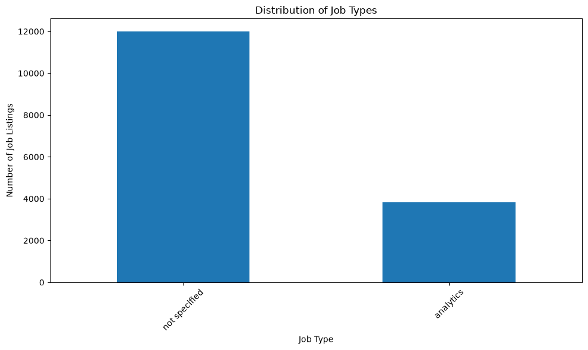

```python
import matplotlib.pyplot as plt

job_type_counts = analytics_clean["job_type"].value_counts()

plt.figure(figsize=(10, 6))

job_type_counts.plot(kind="bar")

plt.title("Distribution of Job Types")
plt.xlabel("Job Type")
plt.ylabel("Number of Job Listings")
plt.xticks(rotation=45)
plt.tight_layout()

plt.show()
```

```python
job_type_percentage = (
    analytics_clean["job_type"]
    .value_counts(normalize=True)
    .mul(100)
    .round(2)
)

display(job_type_percentage)
```

```
job_type
not specified    75.82
analytics        24.18
Name: proportion, dtype: float64
```

# 3.3 Experience Level Analysis — Analytics Jobs

The `experience` column represents the experience range requested for each job listing.

Analyzing experience requirements helps us understand whether the Analytics job market is concentrated around entry-level, mid-level, or experienced professionals.

We will examine the frequency and percentage distribution of experience ranges.

```python
experience_counts = (
    analytics_clean["experience"]
    .value_counts()
    .sort_index()
)

display(experience_counts)
```

```
experience
0-0 yrs     124
0-1 yrs     233
0-2 yrs     318
0-3 yrs     224
0-4 yrs     106
           ...
9-10 yrs     11
9-11 yrs     16
9-12 yrs     56
9-13 yrs     23
9-14 yrs    149
Name: count, Length: 128, dtype: int64
```

[figure not shown]

```python
plt.figure(figsize=(12, 6))

experience_counts.plot(kind="bar")

plt.title("Experience Requirements for Analytics Jobs")
plt.xlabel("Experience Range")
plt.ylabel("Number of Job Listings")
plt.xticks(rotation=45)

plt.tight_layout()
plt.show()
```

```python
experience_percentage = (
    analytics_clean["experience"]
    .value_counts(normalize=True)
    .mul(100)
    .round(2)
)

display(experience_percentage)
```

```
experience
5-10 yrs     6.38
2-5 yrs      6.09
3-8 yrs      4.73
2-7 yrs      4.20
3-5 yrs      3.44
             ...
17-19 yrs    0.01
8-8 yrs      0.01
20-26 yrs    0.01
20-25 yrs    0.01
13-16 yrs    0.01
Name: proportion, Length: 128, dtype: float64
```

# 3.4 Location Analysis — Analytics Jobs

The `location` column indicates the geographical locations associated with Analytics job listings.

Analyzing the location distribution helps identify cities and regions with a higher concentration of Analytics opportunities.

We will identify the most frequently occurring locations and visualize the top locations.

```python
location_counts = (
    analytics_clean["location"]
    .value_counts()
)

display(location_counts.head(20))
```

```
location
Bengaluru                    3333
Mumbai                       1992
Gurgaon                      1313
Pune                          945
Hyderabad                     878
Chennai                       786
Delhi NCR                     593
Noida                         403
Delhi NCR, Gurgaon            278
Delhi                         198
Gurgaon, Gurugram             195
Kolkata                       159
Ahmedabad                     150
Navi Mumbai                   114
Kochi                          77
Trivandrum                     72
Mumbai, Mumbai Suburbs         62
Bengaluru, Hyderabad           57
Delhi NCR, Gurgaon, Noida      55
Mumbai, Bengaluru              53
Name: count, dtype: int64
```

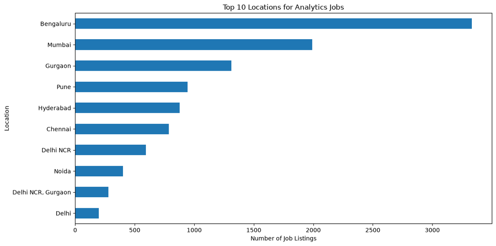

```python
top_locations = location_counts.head(10)

plt.figure(figsize=(12, 6))

top_locations.sort_values().plot(kind="barh")

plt.title("Top 10 Locations for Analytics Jobs")
plt.xlabel("Number of Job Listings")
plt.ylabel("Location")

plt.tight_layout()
plt.show()
```

```python
location_percentage = (
    analytics_clean["location"]
    .value_counts(normalize=True)
    .mul(100)
    .round(2)
)

display(location_percentage.head(10))
```

```
location
Bengaluru             21.04
Mumbai                12.57
Gurgaon                8.29
Pune                   5.97
Hyderabad              5.54
Chennai                4.96
Delhi NCR              3.74
Noida                  2.54
Delhi NCR, Gurgaon     1.75
Delhi                  1.25
Name: proportion, dtype: float64
```

### Interpretation

The location analysis identifies the geographical areas with the highest concentration of Analytics job listings.

The top locations indicate where demand for Analytics professionals is most concentrated in the dataset. This information can help job seekers understand geographical opportunities and can also support location-based career recommendations.

# 3.5 Salary Analysis — Analytics Jobs

The `salary` column contains salary ranges associated with Analytics job listings.

The salary information is examined to understand the distribution of compensation levels across the Analytics job market.

Because salary is stored as a range, we will extract the minimum and maximum salary values and calculate a midpoint salary for analysis.

```python
print("Unique salary values:")
display(analytics_clean["salary"].value_counts())
```

```
Unique salary values:
```

```
salary
10to15    3608
15to25    3281
6to10     2876
0to3      2592
3to6      2239
25to50    1245
Name: count, dtype: int64
```

```python
# Extract minimum and maximum salary from the salary range

analytics_clean["min_salary"] = (
    analytics_clean["salary"]
    .astype(str)
    .str.extract(r"(\d+(?:\.\d+)?)")[0]
    .astype(float)
)

analytics_clean["max_salary"] = (
    analytics_clean["salary"]
    .astype(str)
    .str.extract(r"to(\d+(?:\.\d+)?)")[0]
    .astype(float)
)

# Calculate midpoint salary

analytics_clean["avg_salary"] = (
    analytics_clean["min_salary"] +
    analytics_clean["max_salary"]
) / 2

display(
    analytics_clean[
        ["salary", "min_salary", "max_salary", "avg_salary"]
    ].head(10)
)
```

|  | salary | min_salary | max_salary | avg_salary |
| --- | --- | --- | --- | --- |
| 0 | 6to10 | 6.0 | 10.0 | 8.0 |
| 1 | 10to15 | 10.0 | 15.0 | 12.5 |
| 2 | 0to3 | 0.0 | 3.0 | 1.5 |
| 3 | 6to10 | 6.0 | 10.0 | 8.0 |
| 4 | 10to15 | 10.0 | 15.0 | 12.5 |
| 5 | 15to25 | 15.0 | 25.0 | 20.0 |
| 6 | 3to6 | 3.0 | 6.0 | 4.5 |
| 7 | 0to3 | 0.0 | 3.0 | 1.5 |
| 8 | 6to10 | 6.0 | 10.0 | 8.0 |
| 9 | 0to3 | 0.0 | 3.0 | 1.5 |

```python
print("Salary Statistics")

display(
    analytics_clean[
        ["min_salary", "max_salary", "avg_salary"]
    ].describe()
)
```

```
Salary Statistics
```

|  | min_salary | max_salary | avg_salary |
| --- | --- | --- | --- |
| count | 15841.000000 | 15841.000000 | 15841.000000 |
| mean | 8.862635 | 15.678619 | 12.270627 |
| std | 6.911166 | 12.493526 | 9.656391 |
| min | 0.000000 | 3.000000 | 1.500000 |
| 25% | 3.000000 | 6.000000 | 4.500000 |
| 50% | 10.000000 | 15.000000 | 12.500000 |
| 75% | 15.000000 | 25.000000 | 20.000000 |
| max | 25.000000 | 50.000000 | 37.500000 |

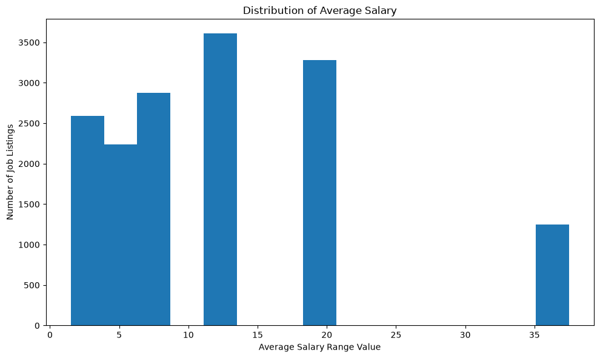

```python
plt.figure(figsize=(10, 6))

analytics_clean["avg_salary"].dropna().plot(
    kind="hist",
    bins=15
)

plt.title("Distribution of Average Salary")
plt.xlabel("Average Salary Range Value")
plt.ylabel("Number of Job Listings")

plt.tight_layout()
plt.show()
```

```python
salary_experience = (
    analytics_clean
    .groupby("experience")["avg_salary"]
    .mean()
    .sort_values(ascending=False)
)

display(salary_experience)
```

```
experience
15-21 yrs    37.500000
13-18 yrs    37.500000
17-25 yrs    37.500000
17-24 yrs    37.500000
17-19 yrs    37.500000
               ...
0-4 yrs       2.740566
0-2 yrs       2.658805
0-1 yrs       2.375536
0-0 yrs       2.233871
2-2 yrs       1.500000
Name: avg_salary, Length: 128, dtype: float64
```

[figure not shown]

```python
plt.figure(figsize=(12, 6))

salary_experience.sort_values().plot(kind="barh")

plt.title("Average Salary by Experience Level")
plt.xlabel("Average Salary")
plt.ylabel("Experience Level")

plt.tight_layout()
plt.show()
```

### Salary Analysis — Interpretation

The salary analysis converts the reported salary ranges into minimum, maximum, and midpoint values.

The midpoint salary is used as an approximate numerical representation of each salary range.

The relationship between experience level and average salary is then examined to understand how compensation varies across different career stages.

This analysis can support career recommendations by showing the potential compensation associated with different experience levels.

# 3.6 Key Skills Analysis — Analytics Jobs

The `key_skills` column contains the skills associated with each Analytics job listing.

The objective is to identify the most frequently requested skills in the job market.

Because a single job listing may contain multiple skills, the skill text must be split into individual skills before calculating frequencies.

```python
print("Sample key skills:")

display(
    analytics_clean["key_skills"].head(20)
)
```

```
Sample key skills:
```

```
0     Oracle SQL, PLSQL, PL, Oracle Forms, Oracle Re...
1     Javascript, HTML, JQuery, Web Development, Pla...
2                SNOW, Servicenow, Servicenow Developer
3     QTP, Flex, LAN, Application support, Performan...
4     HyperMesh, LS - DYNA, NASTRAN, Abaqus, Fatigue...
5     Manager - Portfolio Analytics, Portfolio Analy...
6     Project Management, Client Interfacing, Client...
7     Analysis, research, analyst, research analyst,...
8     SEO, Digital Marketing, Search Engine Marketin...
9     recovery, team handling, data analysis, team l...
10    Analytics, Data analysis, Data mining, SQL, Tr...
11    Data Science, SCALA, Machine Learning, Java, P...
12    Java, J2Ee, Spring Framework, Hadoop, Mapreduc...
13    POC, Data Analytics, Big Data, Data Modeling, ...
14    process monitoring, cost reduction initiatives...
15    background verification, backend, back office,...
16    spark, big data analytics, data analysis, soft...
17    Digital Marketing, Content Strategy, Digital M...
18    finance, auditing, accounting, financial repor...
19    Product Sales, Product Marketing, Product Mana...
Name: key_skills, dtype: str
```

```python
display(
    analytics_clean["key_skills"]
    .value_counts()
    .head(20)
)
```

```
key_skills
part time, freelancing, data entry, present job, work from home...                66
SAS, Sdtm, Adam, Statistical Programming, Statistics, Life Sciences...            15
Ar Calling, ar analyst, accounts receivable, revenue cycle management...          14
Communication Skills, Analytical, Problem Solving, itil solving...                13
Fraud Analytics, People Management Skills, Team Leading, Problem Solving...       13
SAS, Logistic Regression, Chaid, R, Data Analytics, Anova, Excel...               13
Analytics, SAS, banking, insurance, Analytics Head                                12
Linear Regression, Insurance Analytics, Business Analysis...                      12
Excel, SQL, Data Analysis, Segmentation, SAS, Data Mining, SPSS...                12
data entry operation, typing, excel, notepad, freelancing, content writing,...    12
Linux, Windows, Troubleshooting, Network security, Salesforce, Outsourcing,...    11
Legal Process Outsourcing, Business Solutions, Business Services...               10
business analysis, System Analyst, Business Analyst...                            10
Action Request System, ITSM, Bmc Remedy, ITIL, Technical Support...               10
sales management, business development management, lead generation...             10
NoSQL, Spark, Mapreduce, SQL, Cassandra, Data Science, SCALA, Big Data...         10
POC, Data Analytics, Big Data, Data Modeling, Data Management...                   9
Maximo, Business process, Outsourcing, Analytical, Operations, Supervision,...     9
Data analysis, SQL, Consulting, Data management, SPSS, FMCG, Analytical...         9
semi voice process, semi voice, non voice, non voice process, fresher...           9
Name: count, dtype: int64
```

```python
skills_series = (
    analytics_clean["key_skills"]
    .dropna()
    .astype(str)
    .str.split(",")
    .explode()
    .str.strip()
    .str.lower()
)

skill_counts = skills_series.value_counts()

display(skill_counts.head(20))
```

```
key_skills
...                   946
sql                   915
analytics             904
python                840
finance               756
java                  726
r                     655
sas                   636
business analysis     633
machine learning      629
data analysis         618
digital marketing     566
javascript            535
project management    505
seo                   495
data analytics        412
sales                 404
excel                 393
accounting            376
outsourcing           360
Name: count, dtype: int64
```

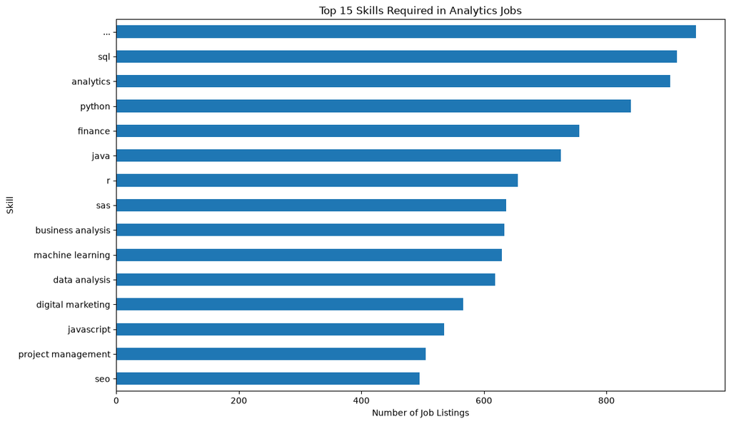

```python
top_skills = skill_counts.head(15)

plt.figure(figsize=(12, 7))

top_skills.sort_values().plot(kind="barh")

plt.title("Top 15 Skills Required in Analytics Jobs")
plt.xlabel("Number of Job Listings")
plt.ylabel("Skill")

plt.tight_layout()
plt.show()
```

```python
skill_percentage = (
    skills_series
    .value_counts(normalize=True)
    .mul(100)
    .round(2)
)

display(skill_percentage.head(15))
```

```
key_skills
...                   1.18
sql                   1.15
analytics             1.13
python                1.05
finance               0.95
java                  0.91
r                     0.82
sas                   0.80
business analysis     0.79
machine learning      0.79
data analysis         0.77
digital marketing     0.71
javascript            0.67
project management    0.63
seo                   0.62
Name: proportion, dtype: float64
```

### Key Skills — Interpretation

The skill-frequency analysis identifies the skills most frequently associated with Analytics job postings.

The most frequently occurring skills represent areas of higher demand within the dataset.

These results can later be compared with the skill-trait datasets to identify potential skill gaps and support career recommendations.

```python
# Inspect how skills are stored

display(
    analytics_clean["key_skills"]
    .dropna()
    .astype(str)
    .head(20)
)
```

```
0     Oracle SQL, PLSQL, PL, Oracle Forms, Oracle Re...
1     Javascript, HTML, JQuery, Web Development, Pla...
2                SNOW, Servicenow, Servicenow Developer
3     QTP, Flex, LAN, Application support, Performan...
4     HyperMesh, LS - DYNA, NASTRAN, Abaqus, Fatigue...
5     Manager - Portfolio Analytics, Portfolio Analy...
6     Project Management, Client Interfacing, Client...
7     Analysis, research, analyst, research analyst,...
8     SEO, Digital Marketing, Search Engine Marketin...
9     recovery, team handling, data analysis, team l...
10    Analytics, Data analysis, Data mining, SQL, Tr...
11    Data Science, SCALA, Machine Learning, Java, P...
12    Java, J2Ee, Spring Framework, Hadoop, Mapreduc...
13    POC, Data Analytics, Big Data, Data Modeling, ...
14    process monitoring, cost reduction initiatives...
15    background verification, backend, back office,...
16    spark, big data analytics, data analysis, soft...
17    Digital Marketing, Content Strategy, Digital M...
18    finance, auditing, accounting, financial repor...
19    Product Sales, Product Marketing, Product Mana...
Name: key_skills, dtype: str
```

```python
skills_series = (
    analytics_clean["key_skills"]
    .dropna()
    .astype(str)
    .str.split(",")
    .explode()
    .str.strip()
    .str.lower()
)

skill_counts = skills_series.value_counts()

display(skill_counts.head(20))
```

```
key_skills
...                   946
sql                   915
analytics             904
python                840
finance               756
java                  726
r                     655
sas                   636
business analysis     633
machine learning      629
data analysis         618
digital marketing     566
javascript            535
project management    505
seo                   495
data analytics        412
sales                 404
excel                 393
accounting            376
outsourcing           360
Name: count, dtype: int64
```

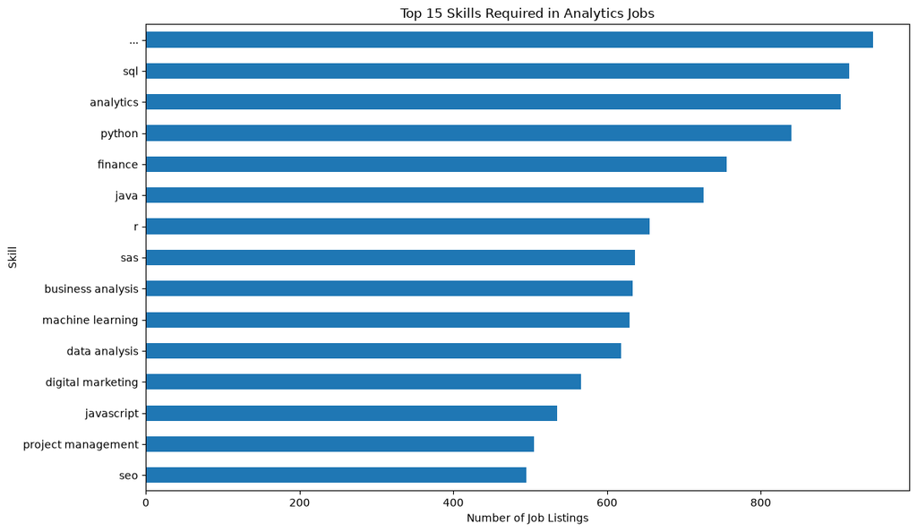

```python
top_skills = skill_counts.head(15)

plt.figure(figsize=(12, 7))

top_skills.sort_values().plot(kind="barh")

plt.title("Top 15 Skills Required in Analytics Jobs")
plt.xlabel("Number of Job Listings")
plt.ylabel("Skill")

plt.tight_layout()
plt.show()
```

```python
skill_percentage = (
    skills_series
    .value_counts(normalize=True)
    .mul(100)
    .round(2)
)

display(skill_percentage.head(15))
```

```
key_skills
...                   1.18
sql                   1.15
analytics             1.13
python                1.05
finance               0.95
java                  0.91
r                     0.82
sas                   0.80
business analysis     0.79
machine learning      0.79
data analysis         0.77
digital marketing     0.71
javascript            0.67
project management    0.63
seo                   0.62
Name: proportion, dtype: float64
```

```python
# 3.6 Key Skills Analysis

# Convert skill text into individual skills
skills_series = (
    analytics_clean["key_skills"]
    .dropna()
    .astype(str)
    .str.split(r"[,;|]")
    .explode()
    .str.strip()
    .str.lower()
)

# Remove empty values
skills_series = skills_series[
    skills_series.str.len() > 0
]

skill_counts = skills_series.value_counts()

display(skill_counts.head(20))
```

```
key_skills
...                   956
sql                   915
analytics             904
python                840
finance               756
java                  726
r                     655
sas                   636
business analysis     633
machine learning      629
data analysis         618
digital marketing     566
javascript            535
project management    505
seo                   495
data analytics        412
sales                 404
excel                 393
accounting            376
outsourcing           360
Name: count, dtype: int64
```

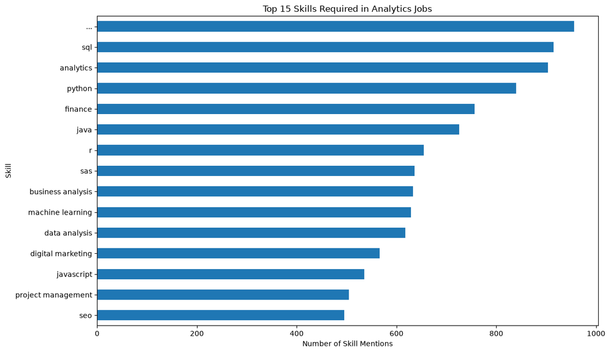

```python
top_skills = skill_counts.head(15)

plt.figure(figsize=(12, 7))

top_skills.sort_values().plot(kind="barh")

plt.title("Top 15 Skills Required in Analytics Jobs")
plt.xlabel("Number of Skill Mentions")
plt.ylabel("Skill")

plt.tight_layout()
plt.show()
```

```python
skill_percentage = (
    skill_counts
    .div(len(skills_series))
    .mul(100)
    .round(2)
)

display(skill_percentage.head(15))
```

```
key_skills
...                   1.20
sql                   1.14
analytics             1.13
python                1.05
finance               0.95
java                  0.91
r                     0.82
sas                   0.80
business analysis     0.79
machine learning      0.79
data analysis         0.77
digital marketing     0.71
javascript            0.67
project management    0.63
seo                   0.62
Name: count, dtype: float64
```

### Key Skills — Interpretation

The key-skills analysis identifies the skills most frequently associated with Analytics job listings.

The most frequently occurring skills represent areas of higher demand within the dataset.

These results can later be compared with the JDS Skill Traits dataset to understand the relationship between job-market demand and skill traits.

# 3.7 JDS Skill Traits Analysis

The JDS Skill Traits dataset contains skill-related traits associated with job roles.

The objective is to understand which skills or traits appear most frequently and compare them with the skills observed in Analytics job listings.

```python
display(jds_clean.head())
print(jds_clean.columns.tolist())
```

|  | id | big_data_skills | maths-stats_skills | coding_skills | ai_and_ml_skills | dashboard_and_storytelling_skills | salary_hike_high_or_low |
| --- | --- | --- | --- | --- | --- | --- | --- |
| 0 | 2809 | 3.6 | 4.0 | 4.5 | 4.8 | 5.0 | 1 |
| 1 | 2231 | 5.0 | 3.8 | 3.3 | 5.0 | 4.4 | 0 |
| 2 | 3522 | 4.1 | 3.8 | 4.4 | 4.2 | 5.0 | 1 |
| 3 | 3291 | 4.4 | 3.0 | 3.3 | 4.6 | 2.3 | 0 |
| 4 | 3424 | 2.3 | 2.3 | 2.6 | 3.3 | 3.0 | 0 |

```
['id', 'big_data_skills', 'maths-stats_skills', 'coding_skills', 'ai_and_ml_skills', 'dashboard_and_storytelling_skills', 'salary_hike_high_or_low']
```

```python
for col in jds_clean.columns:
    print(f"\n--- {col} ---")
    display(jds_clean[col].value_counts().head(10))
```

```
--- id ---
```

```
id
3291    2
2223    2
2809    1
2231    1
3522    1
3424    1
3757    1
2544    1
3482    1
3702    1
Name: count, dtype: int64
```

```
--- big_data_skills ---
```

```
big_data_skills
5.0    25
3.8     8
3.5     8
2.9     8
3.6     7
4.1     7
3.1     7
4.4     6
3.0     6
2.4     4
Name: count, dtype: int64
```

```
--- maths-stats_skills ---
```

```
maths-stats_skills
5.0    57
3.8    11
4.4     7
4.9     7
4.5     6
4.0     5
2.7     4
3.9     4
4.6     4
2.3     3
Name: count, dtype: int64
```

```
--- coding_skills ---
```

```
coding_skills
5.0    62
4.6    10
4.4     9
3.3     7
3.2     6
3.9     5
2.9     5
2.6     4
2.3     4
4.5     3
Name: count, dtype: int64
```

```
--- ai_and_ml_skills ---
```

```
ai_and_ml_skills
5.0    68
4.8    11
4.6    10
4.9     6
4.2     5
3.0     5
4.7     5
4.3     4
4.4     3
4.5     3
Name: count, dtype: int64
```

```
--- dashboard_and_storytelling_skills ---
```

```
dashboard_and_storytelling_skills
5.0    81
4.4     6
2.9     6
2.3     5
2.5     5
3.0     4
3.3     4
4.6     4
4.8     3
3.9     3
Name: count, dtype: int64
```

```
--- salary_hike_high_or_low ---
```

```
salary_hike_high_or_low
1    73
0    66
Name: count, dtype: int64
```

# 3.8 SDS Personality Traits Analysis

The SDS Personality Traits dataset provides personality-related traits associated with job roles.

The purpose of this analysis is to understand the personality characteristics associated with different career/job profiles.

```python
display(sds_clean.head())
print(sds_clean.columns.tolist())
```

|  | id | neuroticism | extraversion | openness_to_experience | agreeableness | conscientiousness | success_ classification_ high_low |
| --- | --- | --- | --- | --- | --- | --- | --- |
| 0 | 8120 | 33 | 34 | 39 | 45 | 51 | 1 |
| 1 | 8951 | 50 | 36 | 31 | 59 | 39 | 0 |
| 2 | 8656 | 38 | 35 | 42 | 39 | 49 | 1 |
| 3 | 8796 | 41 | 26 | 30 | 40 | 19 | 0 |
| 4 | 8470 | 20 | 17 | 21 | 31 | 26 | 0 |

```
['id', 'neuroticism', ' extraversion', 'openness_to_experience', 'agreeableness', 'conscientiousness', 'success_ classification_ high_low']
```

```python
for col in sds_clean.columns:
    print(f"\n--- {col} ---")
    display(sds_clean[col].value_counts().head(10))
```

```
--- id ---
```

```
id
8656    2
8303    2
8198    2
8228    2
8065    2
8308    2
8489    2
8301    2
8887    2
8120    1
Name: count, dtype: int64
```

```
--- neuroticism ---
```

```
neuroticism
27    12
44     9
33     8
40     7
23     7
35     7
41     6
31     6
34     6
28     6
Name: count, dtype: int64
```

```
---  extraversion ---
```

```
 extraversion
50    8
46    8
54    7
51    7
53    6
45    6
47    6
36    5
22    5
56    5
Name: count, dtype: int64
```

```
--- openness_to_experience ---
```

```
openness_to_experience
49    10
44    10
47     9
46     7
53     7
43     7
45     7
42     6
24     6
48     6
Name: count, dtype: int64
```

```
--- agreeableness ---
```

```
agreeableness
46    14
49    11
45     9
50     8
48     7
43     7
42     5
51     5
64     5
39     4
Name: count, dtype: int64
```

```
--- conscientiousness ---
```

```
conscientiousness
51    8
49    8
57    8
52    7
24    7
50    6
44    6
54    6
56    5
58    5
Name: count, dtype: int64
```

```
--- success_ classification_ high_low ---
```

```
success_ classification_ high_low
1    85
0    76
Name: count, dtype: int64
```

# 3.9 Cross-Dataset Comparison

The four datasets provide different perspectives on the job market:

1. Analytics Jobs — job demand, experience, location, salary and skills
2. Data Science Jobs — Data Science job-market information
3. JDS Skill Traits — skill-related traits
4. SDS Personality Traits — personality-related traits

Combining these perspectives can help connect job-market demand with skills and personality characteristics.

```python
dataset_sizes = pd.DataFrame({
    "Dataset": [
        "Analytics Jobs",
        "Data Science Jobs",
        "JDS Skill Traits",
        "SDS Personality Traits"
    ],
    "Rows": [
        len(analytics_clean),
        len(ds_jobs_clean),
        len(jds_clean),
        len(sds_clean)
    ],
    "Columns": [
        analytics_clean.shape[1],
        ds_jobs_clean.shape[1],
        jds_clean.shape[1],
        sds_clean.shape[1]
    ]
})

display(dataset_sizes)
```

|  | Dataset | Rows | Columns |
| --- | --- | --- | --- |
| 0 | Analytics Jobs | 15841 | 11 |
| 1 | Data Science Jobs | 1602 | 8 |
| 2 | JDS Skill Traits | 139 | 7 |
| 3 | SDS Personality Traits | 161 | 7 |

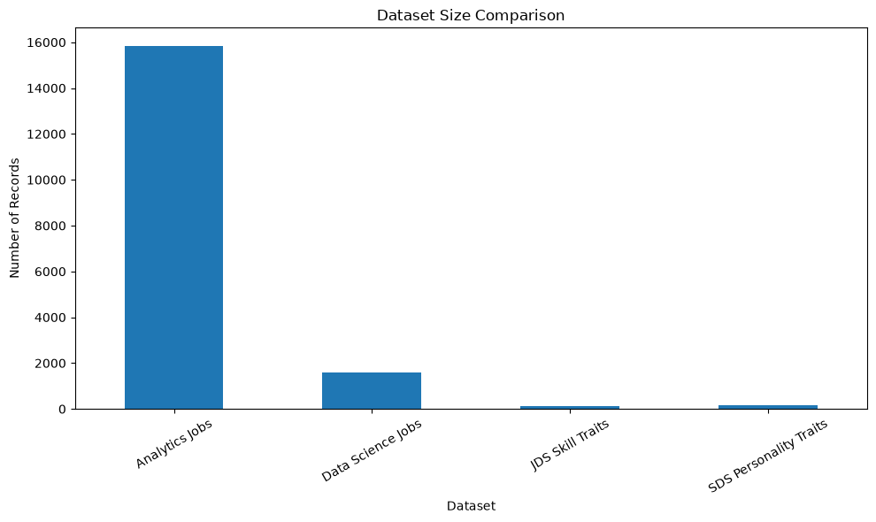

```python
plt.figure(figsize=(10, 6))

dataset_sizes.set_index("Dataset")["Rows"].plot(kind="bar")

plt.title("Dataset Size Comparison")
plt.xlabel("Dataset")
plt.ylabel("Number of Records")

plt.xticks(rotation=30)
plt.tight_layout()
plt.show()
```

# 3.10 Data Science Jobs Analysis

The Data Science Jobs dataset is analyzed separately to understand the characteristics of Data Science opportunities.

We examine the available categorical variables and identify the most frequent values.

```python
for col in ds_jobs_clean.columns:
    if ds_jobs_clean[col].dtype == "object":
        print(f"\n--- {col} ---")
        display(ds_jobs_clean[col].value_counts().head(10))
```

[output not shown]

```python
for col in ds_jobs_clean.columns:
    if ds_jobs_clean[col].dtype == "object":
        print(f"\n--- {col} ---")
        display(ds_jobs_clean[col].value_counts().head(10))
```

[output not shown]

# 4. Final Insights

The exploratory analysis provides several important perspectives on the job market.

### Job Market

The Analytics Jobs dataset contains the largest number of records among the four datasets, making it the primary source for understanding Analytics job-market patterns.

### Experience

The experience analysis shows how Analytics opportunities are distributed across different experience requirements.

### Location

The location analysis identifies the geographical areas with the highest concentration of Analytics job listings.

### Salary

Salary ranges were converted into approximate minimum, maximum and midpoint values to enable numerical analysis.

The midpoint should be treated as an approximate representation of the reported salary range rather than an exact salary.

### Skills

The skill analysis identifies the most frequently requested skills in Analytics job postings.

### Skill Traits

The JDS Skill Traits dataset provides additional information about skill-related characteristics that can be compared with job-market demand.

### Personality Traits

The SDS Personality Traits dataset adds a personality dimension to the analysis and can support broader career-profile analysis.

### Overall

Together, these datasets provide a foundation for connecting:

Job Demand → Skills → Experience → Salary → Location → Skill Traits → Personality Traits

This can support data-driven career and job-role recommendations.

```python
analytics_clean.to_csv(
    CLEAN_DIR / "Analytics_Jobs_Cleaned.csv",
    index=False
)

ds_jobs_clean.to_csv(
    CLEAN_DIR / "Data_Science_Jobs_Cleaned.csv",
    index=False
)

jds_clean.to_csv(
    CLEAN_DIR / "JDS_Skill_Traits_Cleaned.csv",
    index=False
)

sds_clean.to_csv(
    CLEAN_DIR / "SDS_Personality_Traits_Cleaned.csv",
    index=False
)

print("All cleaned datasets saved successfully.")
```

```
All cleaned datasets saved successfully.
```

# Conclusion

This project performed a complete exploratory analysis of four related datasets covering Analytics jobs, Data Science jobs, skill traits and personality traits.

The workflow included:

- Data loading
- Data-quality investigation
- Missing-value analysis
- Duplicate checking
- Data cleaning
- Data validation
- Job-type analysis
- Experience analysis
- Location analysis
- Salary analysis
- Skill-frequency analysis
- Skill-trait analysis
- Personality-trait analysis
- Cross-dataset comparison

The cleaned datasets and exploratory findings provide a foundation for developing a data-driven career intelligence and recommendation system.

The next stage can use these findings to build role matching, skill-gap analysis and career recommendations.